# Table of Contents

## *Merging/Grouping/Concatinating/Pivoting*

- Ill divide the pokemon data to 2 DataFrames to use for the merge/grouping and pivoting examples
- The 2 dataframes will share the id column called '#'

```python
original_pokemon = pd.read_csv('pokemon.csv')
pokemon1 = original_pokemon.loc[:,['#','Name','Type 1','Type 2','Total','HP','Attack','Defense']]
pokemon2 = original_pokemon.loc[:, ['#','Sp. Atk','Sp. Def','Speed','Generation','Legendary']]
```

```python
pokemon1.head()
```

|  | # | Name | Type 1 | Type 2 | Total | HP | Attack | Defense |
| --- | --- | --- | --- | --- | --- | --- | --- | --- |
| 0 | 1 | Bulbasaur | Grass | Poison | 318 | 45 | 49 | 49 |
| 1 | 2 | Ivysaur | Grass | Poison | 405 | 60 | 62 | 63 |
| 2 | 3 | Venusaur | Grass | Poison | 525 | 80 | 82 | 83 |
| 3 | 3 | VenusaurMega Venusaur | Grass | Poison | 625 | 80 | 100 | 123 |
| 4 | 4 | Charmander | Fire | NaN | 309 | 39 | 52 | 43 |

```python
pokemon2.head()
```

|  | # | Sp. Atk | Sp. Def | Speed | Generation | Legendary |
| --- | --- | --- | --- | --- | --- | --- |
| 0 | 1 | 65 | 65 | 45 | 1 | False |
| 1 | 2 | 80 | 80 | 60 | 1 | False |
| 2 | 3 | 100 | 100 | 80 | 1 | False |
| 3 | 3 | 122 | 120 | 80 | 1 | False |
| 4 | 4 | 60 | 50 | 65 | 1 | False |

### pd.merge()

- Example1 - Lets restore the original dataframe(pokemon) by merging pokemon1 and pokemon2

```python
restored_pokemon_dataFrame = pokemon1.merge(pokemon2, on = pokemon1.index, suffixes=('pokemon1_index', 'pokemon2_index'))
```

```python
restored_pokemon_dataFrame.head()
```

|  | key_0 | #pokemon1_index | Name | Type 1 | Type 2 | Total | HP | Attack | Defense | #pokemon2_index | Sp. Atk | Sp. Def | Speed | Generation | Legendary |
| --- | --- | --- | --- | --- | --- | --- | --- | --- | --- | --- | --- | --- | --- | --- | --- |
| 0 | 0 | 1 | Bulbasaur | Grass | Poison | 318 | 45 | 49 | 49 | 1 | 65 | 65 | 45 | 1 | False |
| 1 | 1 | 2 | Ivysaur | Grass | Poison | 405 | 60 | 62 | 63 | 2 | 80 | 80 | 60 | 1 | False |
| 2 | 2 | 3 | Venusaur | Grass | Poison | 525 | 80 | 82 | 83 | 3 | 100 | 100 | 80 | 1 | False |
| 3 | 3 | 3 | VenusaurMega Venusaur | Grass | Poison | 625 | 80 | 100 | 123 | 3 | 122 | 120 | 80 | 1 | False |
| 4 | 4 | 4 | Charmander | Fire | NaN | 309 | 39 | 52 | 43 | 4 | 60 | 50 | 65 | 1 | False |

### pd.merge_ordered()

- merge_ordered method is extremely similar to the regular merge method, it has the same arguments and all.
- The main difference is that merge_ordered order the result table by the key that was merged on, Also the default join type is outer and NOT inner.
- Its good to use instead of the regular merge when working with time-series data, and when we want to fill missing data.

```python
# Use merge_ordered() to merge gdp and sp500, interpolate missing value
gdp_sp500 = pd.merge_ordered(gdp, sp500, left_on='year', right_on='date',
                             how='left',  fill_method='ffill')
```

### pd.groupby() + agg

- Example1 - Grouping and counting the generations in pokemon2

```python
counted_df = pokemon2.groupby('Generation').agg({'Generation':'count'})
counted_df
```

| Generation | Generation |
| --- | --- |
| 1 | 166 |
| 2 | 106 |
| 3 | 160 |
| 4 | 121 |
| 5 | 165 |
| 6 | 82 |

- Example2 - Grouping and averaging the attack per generation

```python
avg_attack_per_generation = restored_pokemon_dataFrame.groupby('Generation').agg({'Attack':'mean'})
avg_attack_per_generation
```

| Generation | Attack |
| --- | --- |
| 1 | 76.638554 |
| 2 | 72.028302 |
| 3 | 81.625000 |
| 4 | 82.867769 |
| 5 | 82.066667 |
| 6 | 75.804878 |

### pd.concat()

pd.concat()

- can concatenate pandas objects along a specific axis, meaning we can choose to merge dataframes vertically or horizontally.
- Example1 - Lets create the same restored_pokemon_dataFrame as earlier by concatenating the data horizontally

```python
restored_pokemon_dataFrame = pd.concat([pokemon1, pokemon2], join = 'inner', axis = 1)
```

```python
restored_pokemon_dataFrame.head()
```

|  | # | Name | Type 1 | Type 2 | Total | HP | Attack | Defense | # | Sp. Atk | Sp. Def | Speed | Generation | Legendary |
| --- | --- | --- | --- | --- | --- | --- | --- | --- | --- | --- | --- | --- | --- | --- |
| 0 | 1 | Bulbasaur | Grass | Poison | 318 | 45 | 49 | 49 | 1 | 65 | 65 | 45 | 1 | False |
| 1 | 2 | Ivysaur | Grass | Poison | 405 | 60 | 62 | 63 | 2 | 80 | 80 | 60 | 1 | False |
| 2 | 3 | Venusaur | Grass | Poison | 525 | 80 | 82 | 83 | 3 | 100 | 100 | 80 | 1 | False |
| 3 | 3 | VenusaurMega Venusaur | Grass | Poison | 625 | 80 | 100 | 123 | 3 | 122 | 120 | 80 | 1 | False |
| 4 | 4 | Charmander | Fire | NaN | 309 | 39 | 52 | 43 | 4 | 60 | 50 | 65 | 1 | False |

- Example2 - Lets try to concatenate the same data vertically and see what happens:

```python
restored_pokemon_dataFrame = pd.concat([pokemon1, pokemon2], join = 'inner', axis = 0)
restored_pokemon_dataFrame
```

|  | # |
| --- | --- |
| 0 | 1 |
| 1 | 2 |
| 2 | 3 |
| 3 | 3 |
| 4 | 4 |
| ... | ... |
| 795 | 719 |
| 796 | 719 |
| 797 | 720 |
| 798 | 720 |
| 799 | 721 |

1600 rows × 1 columns

- As we can see Pandas found the column that both dataframes share and concatenated iter
- The other columns did not concatenated because the 2 dataframes dont share them

### pd.append()

- Append rows of other objects to the end of the original object, returning a new object.

### pd.melt(id_vars = ['column1', "column2"], value_vars = ["value1", "value2"])

```python
pokemon.head()
```

|  | # | Name | Type 1 | Type 2 | Total | HP | Attack | Defense | Sp. Atk | Sp. Def | Speed | Generation | Legendary |
| --- | --- | --- | --- | --- | --- | --- | --- | --- | --- | --- | --- | --- | --- |
| 0 | 1 | Bulbasaur | Grass | Poison | 318 | 45 | 49 | 49 | 65 | 65 | 45 | 1 | False |
| 1 | 2 | Ivysaur | Grass | Poison | 405 | 60 | 62 | 63 | 80 | 80 | 60 | 1 | False |
| 2 | 3 | Venusaur | Grass | Poison | 525 | 80 | 82 | 83 | 100 | 100 | 80 | 1 | False |
| 3 | 3 | VenusaurMega Venusaur | Grass | Poison | 625 | 80 | 100 | 123 | 122 | 120 | 80 | 1 | False |
| 4 | 4 | Charmander | Fire | NaN | 309 | 39 | 52 | 43 | 60 | 50 | 65 | 1 | False |

```python
pd.melt(pokemon, id_vars=['Generation','Legendary'])
```

|  | Generation | Legendary | variable | value |
| --- | --- | --- | --- | --- |
| 0 | 1 | False | # | 1 |
| 1 | 1 | False | # | 2 |
| 2 | 1 | False | # | 3 |
| 3 | 1 | False | # | 3 |
| 4 | 1 | False | # | 4 |
| ... | ... | ... | ... | ... |
| 8795 | 6 | True | Speed | 50 |
| 8796 | 6 | True | Speed | 110 |
| 8797 | 6 | True | Speed | 70 |
| 8798 | 6 | True | Speed | 80 |
| 8799 | 6 | True | Speed | 70 |

8800 rows × 4 columns

```python
pd.melt(pokemon, id_vars=['Generation','Legendary'], value_vars=['Attack'], value_name='Attack_of_Pokemon')
```

|  | Generation | Legendary | variable | Attack_of_Pokemon |
| --- | --- | --- | --- | --- |
| 0 | 1 | False | Attack | 49 |
| 1 | 1 | False | Attack | 62 |
| 2 | 1 | False | Attack | 82 |
| 3 | 1 | False | Attack | 100 |
| 4 | 1 | False | Attack | 52 |
| ... | ... | ... | ... | ... |
| 795 | 6 | True | Attack | 100 |
| 796 | 6 | True | Attack | 160 |
| 797 | 6 | True | Attack | 110 |
| 798 | 6 | True | Attack | 160 |
| 799 | 6 | True | Attack | 110 |

800 rows × 4 columns

## *DataFrame Aggregation*

### mean/median

```python
data.mean()
```

```
Unnamed: 0        2.500000e+01
individuals       7.225784e+03
family_members    3.504882e+03
state_pop         6.405637e+06
total             1.073067e+04
dtype: float64
```

```python
data['state_pop'].mean()
```

```
6405637.274509804
```

```python
data['state_pop'].median()
```

```
4461153.0
```

### info/describe

```python
data.info()
```

```
<class 'pandas.core.frame.DataFrame'>
RangeIndex: 51 entries, 0 to 50
Data columns (total 7 columns):
 #   Column          Non-Null Count  Dtype
---  ------          --------------  -----
 0   Unnamed: 0      51 non-null     int64
 1   region          51 non-null     object
 2   state           51 non-null     object
 3   individuals     51 non-null     float64
 4   family_members  51 non-null     float64
 5   state_pop       51 non-null     int64
 6   total           51 non-null     float64
dtypes: float64(3), int64(2), object(2)
memory usage: 2.9+ KB
```

```python
data.describe()
```

|  | Unnamed: 0 | individuals | family_members | state_pop | total |
| --- | --- | --- | --- | --- | --- |
| count | 51.000000 | 51.000000 | 51.000000 | 5.100000e+01 | 51.000000 |
| mean | 25.000000 | 7225.784314 | 3504.882353 | 6.405637e+06 | 10730.666667 |
| std | 14.866069 | 15991.025083 | 7805.411811 | 7.327258e+06 | 21777.558637 |
| min | 0.000000 | 434.000000 | 75.000000 | 5.776010e+05 | 542.000000 |
| 25% | 12.500000 | 1446.500000 | 592.000000 | 1.777414e+06 | 2318.500000 |
| 50% | 25.000000 | 3082.000000 | 1482.000000 | 4.461153e+06 | 4907.000000 |
| 75% | 37.500000 | 6781.500000 | 3196.000000 | 7.340946e+06 | 9448.500000 |
| max | 50.000000 | 109008.000000 | 52070.000000 | 3.946159e+07 | 129972.000000 |

### pd.agg()

- The agg method applies a function to a Pandas Series
- For example, lets apply a function that calculates the difference between the mean and the median of a certrain column, and apply it on temerature_c and weekly_sales

```python
sales = pd.read_csv('sales_subset.csv')
sales.head()
```

|  | Unnamed: 0 | store | type | department | date | weekly_sales | is_holiday | temperature_c | fuel_price_usd_per_l | unemployment |
| --- | --- | --- | --- | --- | --- | --- | --- | --- | --- | --- |
| 0 | 0 | 1 | A | 1 | 2010-02-05 | 24924.50 | False | 5.727778 | 0.679451 | 8.106 |
| 1 | 1 | 1 | A | 1 | 2010-03-05 | 21827.90 | False | 8.055556 | 0.693452 | 8.106 |
| 2 | 2 | 1 | A | 1 | 2010-04-02 | 57258.43 | False | 16.816667 | 0.718284 | 7.808 |
| 3 | 3 | 1 | A | 1 | 2010-05-07 | 17413.94 | False | 22.527778 | 0.748928 | 7.808 |
| 4 | 4 | 1 | A | 1 | 2010-06-04 | 17558.09 | False | 27.050000 | 0.714586 | 7.808 |

```python
def mean_median_difference(column):
    return column.mean() - column.median()
```

```python
sales['temperature_c'].agg(mean_median_difference)
```

```
-1.234688447497172
```

```python
sales['weekly_sales'].agg(mean_median_difference)
```

```
11794.88514850567
```

- Another Example, applying the iqr function on temperature_c

```python
# A custom IQR function
def iqr(column):
    return column.quantile(0.75) - column.quantile(0.25)

# Print IQR of the temperature_c column
print(sales['temperature_c'].agg(iqr))
```

```
16.58333333333334
```

### From this point Ill try to work with the pokemn data set

```python
pokemon = pd.read_csv('Pokemon.csv')
pokemon.head()
```

|  | # | Name | Type 1 | Type 2 | Total | HP | Attack | Defense | Sp. Atk | Sp. Def | Speed | Generation | Legendary |
| --- | --- | --- | --- | --- | --- | --- | --- | --- | --- | --- | --- | --- | --- |
| 0 | 1 | Bulbasaur | Grass | Poison | 318 | 45 | 49 | 49 | 65 | 65 | 45 | 1 | False |
| 1 | 2 | Ivysaur | Grass | Poison | 405 | 60 | 62 | 63 | 80 | 80 | 60 | 1 | False |
| 2 | 3 | Venusaur | Grass | Poison | 525 | 80 | 82 | 83 | 100 | 100 | 80 | 1 | False |
| 3 | 3 | VenusaurMega Venusaur | Grass | Poison | 625 | 80 | 100 | 123 | 122 | 120 | 80 | 1 | False |
| 4 | 4 | Charmander | Fire | NaN | 309 | 39 | 52 | 43 | 60 | 50 | 65 | 1 | False |

### pd.cumsum()/pd.cummax()

### cumsum()

- Calculates the cumulative sum of a Pandas Series

```python
total_stats = pokemon['Total']
total_stats
```

```
0      318
1      405
2      525
3      625
4      309
      ...
795    600
796    700
797    600
798    680
799    600
Name: Total, Length: 800, dtype: int64
```

```python
total_stats_cumsum = total_stats.cumsum()
total_stats_cumsum
```

```
0         318
1         723
2        1248
3        1873
4        2182
        ...
795    345502
796    346202
797    346802
798    347482
799    348082
Name: Total, Length: 800, dtype: int64
```

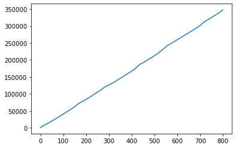

```python
total_stats_cumsum.plot()
```

### cummax()

- Calculates the cumulative max values of a Pandas Series

```python
total_stats = pokemon['Total']
total_stats
```

```
0      318
1      405
2      525
3      625
4      309
      ...
795    600
796    700
797    600
798    680
799    600
Name: Total, Length: 800, dtype: int64
```

```python
total_stats_cummax = total_stats.cummax()
total_stats_cummax
```

```
0      318
1      405
2      525
3      625
4      625
      ...
795    780
796    780
797    780
798    780
799    780
Name: Total, Length: 800, dtype: int64
```

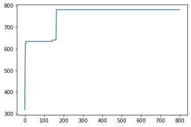

```python
total_stats_cummax.plot()
```

## General Tips & Tricks

### Turning a Pandas Series into a string series

```python
pokemon.Name
```

```
0                  Bulbasaur
1                    Ivysaur
2                   Venusaur
3      VenusaurMega Venusaur
4                 Charmander
               ...
795                  Diancie
796      DiancieMega Diancie
797      HoopaHoopa Confined
798       HoopaHoopa Unbound
799                Volcanion
Name: Name, Length: 800, dtype: object
```

```python
pokemon.Name.str
```

```
<pandas.core.strings.StringMethods at 0x1bf37acaf40>
```

```python
type(pokemon.Name.str)
```

```
pandas.core.strings.StringMethods
```

- As we can see, adding a .str turns the series into a stringMethod.
- We can use many of the Python's string methods on the StringMethod, which is quite usefull

# **Numpy**

```python
import numpy as np
```

## Numpy's Methods

```python
arr1 = np.array([1,2,3])
arr2 = np.array([2,3,4])
```

### np.abs()

- Return the absolute value
- Note: Can also use np.absolute, they are completely identical

```python
np.abs(1+2*-5)
```

```
9
```

```python
np.abs(arr1 * -1 * arr2)
```

```
array([ 2,  6, 12])
```

```python
np.absolute(1+2*-5)
```

```
9
```

```python
np.absolute(arr1 * -1 * arr2)
```

```
array([ 2,  6, 12])
```

### np.add()

- Mathematically add elements

```python
np.add(arr1,arr2)
```

```
array([3, 5, 7])
```

- This is the same as this:

```python
arr1 + arr2
```

```
array([3, 5, 7])
```

### np.add_docstring(, )

- Add docstring to an existing function

```python
def test_function():


    print('This function does nothing')
```

```python
print(test_function.__doc__)
```

```
None
```

```python
np.add_docstring(test_function, 'Im adding this docstring to the function')
```

```python
print(test_function.__doc__)
```

```
Im adding this docstring to the function
```

### np.alen()

- Return the number of elements in the array.
- For example, an empty list is considered an element

```python
arr1 = [[1,2,3],[2,3,4]]
arr2 = [1,2,3,4]
arr3 = [[1,2,3,4], [] ]
```

```python
np.alen(arr1)
```

```
2
```

```python
np.alen(arr2)
```

```
4
```

```python
np.alen(arr3)
```

```
2
```

### np.all()

- Test whether all array elements along a given axis evaluate to True.
- For example, lets check if all the animals in the Dataframe df, is older than 15

```python
df
```

|  | animal | age | age_squared |
| --- | --- | --- | --- |
| 0 | dog | 10 | 100 |
| 1 | pig | 20 | 400 |

```python
df.age > 15
```

```
0    False
1     True
Name: age, dtype: bool
```

```python
np.all(a= np.array(df.age > 15))
```

```
False
```

- The answer is No.

### np.allclose(a, b, atol)

- Compare a and b, and if the difference between them is smaller than the tolerance parameter(atol), return True else, False

```python
np.allclose(a=1, b=2, atol=0.5)
```

```
False
```

```python
np.allclose(a=1, b=2, atol=1)
```

```
True
```

### np.alltrue(*args, **kwargs)

- Check if all elements of input array are true.
- This function is similar to np.all()

```python
np.alltrue([True, False])
```

```
False
```

```python
np.all([True, False])
```

```
False
```

### np.amax(), npamin()

- Return the maximum/minimum of an array or maximum along an axis.

```python
np.amax(a=np.array([1,2,3,4]), axis=0)
```

```
4
```

```python
np.amin(a=np.array([1,2,3,4]), axis=0)
```

```
1
```

## np.array Methods

```python
import numpy as np

arr1 = np.array([*range(9)])
arr1
```

```
array([0, 1, 2, 3, 4, 5, 6, 7, 8])
```

```python
np.arr
```

```python
np.array().all
```

# **Strings & Regular Expressions**

-regex is used to process strings and text before applying machine learning algorithms.

- in python, a string is considered a single object
- if we want to access characters within the string we need regex.
- In python we can slice strings( str[1:3]), concat it(str1 + str2), extract (str1[2]), stride(str1[1:8:2] —> meaning all the chars from 1 to 8 with steps of 2)

## Methods

Method Description

- capitalize() Converts the first character to upper case
- casefold() Converts string into lower case
- center() Returns a centered string
- count() Returns the number of times a specified value occurs in a string
- encode() Returns an encoded version of the string
- endswith() Returns true if the string ends with the specified value
- expandtabs() Sets the tab size of the string
- find() Searches the string for a specified value and returns the position of where it was found
- format() Formats specified values in a string
- format_map() Formats specified values in a string
- index() Searches the string for a specified value and returns the position of where it was found
- isalnum() Returns True if all characters in the string are alphanumeric
- isalpha() Returns True if all characters in the string are in the alphabet
- isascii() Returns True if all characters in the string are ascii characters
- isdecimal() Returns True if all characters in the string are decimals
- isdigit() Returns True if all characters in the string are digits
- isidentifier() Returns True if the string is an identifier
- islower() Returns True if all characters in the string are lower case
- isnumeric() Returns True if all characters in the string are numeric
- isprintable() Returns True if all characters in the string are printable
- isspace() Returns True if all characters in the string are whitespaces
- istitle() Returns True if the string follows the rules of a title
- isupper() Returns True if all characters in the string are upper case
- join() Converts the elements of an iterable into a string
- ljust() Returns a left justified version of the string
- lower() Converts a string into lower case
- lstrip() Returns a left trim version of the string
- maketrans() Returns a translation table to be used in translations
- partition() Returns a tuple where the string is parted into three parts
- replace() Returns a string where a specified value is replaced with a specified value
- rfind() Searches the string for a specified value and returns the last position of where it was found
- rindex() Searches the string for a specified value and returns the last position of where it was found
- rjust() Returns a right justified version of the string
- rpartition() Returns a tuple where the string is parted into three parts
- rsplit() Splits the string at the specified separator, and returns a list
- rstrip() Returns a right trim version of the string
- split() Splits the string at the specified separator, and returns a list
- splitlines() Splits the string at line breaks and returns a list
- startswith() Returns true if the string starts with the specified value
- strip() Returns a trimmed version of the string
- swapcase() Swaps cases, lower case becomes upper case and vice versa
- title() Converts the first character of each word to upper case
- translate() Returns a translated string
- upper() Converts a string into upper case
- zfill() Fills the string with a specified number of 0 values at the beginning

### len()

- Extract the length of the string

```python
string = 'i Love Big Butts and i Cannot Lie'
len(string)
```

```
33
```

### index()

- Return the starting location of the substring

```python
string.index('Love')
```

```
2
```

### count()

- Count the occurences of a substring

```python
string.count('i')
```

```
4
```

### isalnum()

- Return True if the string is only number.
- Return False if the string has even one letter.

```python
string = 'i Love Big Butts and i Cannot Lie'
```

```python
string.isalnum()
```

```
False
```

```python
string2 = 'My favoriate number is 1'
```

```python
string2.isalnum()
```

```
False
```

```python
string_number = '1'
```

```python
string_number.isalnum()
```

```
True
```

### isalpha()

- Return true if the string is in alphabetic order(without spaces)

```python
string_abc = 'abc'
```

```python
string_abc.isalpha()
```

```
True
```

```python
string_abcd = 'abcd'
```

```python
string_abcd.isalpha()
```

```
True
```

```python
string_abcd_egf = 'abcd efg'
```

```python
string_abcd_egf.isalpha()
```

```
False
```

### isascii

- Return True if all characters in the string are ASCII, False otherwise.
- Empty string is ASCII too.

```python
string_english = 'i Love Big Butts and i Cannot Lie'
```

```python
string_english.isascii()
```

```
True
```

```python
string_hebrew = 'אני אוהב תחתים גדולים ואני לא יכול לשקר'
```

```python
string_hebrew.isascii()
```

```
False
```

```python
string_characters = '!@$%^&%^(*^(^%))'
```

```python
string_characters.isascii()
```

```
True
```

### isdecimal()

- Return True if the string is a decimal string, False otherwise.

```python
string_words = 'i Love Big Butts and i Cannot Lie'
```

```python
string_integers = '123456'
```

```python
string_words.isdecimal()
```

```
False
```

```python
string_integers.isdecimal()
```

```
True
```

### isdigit()

- Return True if the string is a digit string, False otherwise.

```python
string_words = 'i Love Big Butts and i Cannot Lie'
```

```python
string_integers = '123456'
```

```python
string_words.isdigit()
```

```
False
```

```python
string_integers.isdigit()
```

```
True
```

### isnumeric()

- Return True if the string is a numeric string, False otherwise.

```python
string_words = 'i Love Big Butts and i Cannot Lie'
```

```python
string_integers = '123456'
```

```python
string_words.isnumeric()
```

```
False
```

```python
string_integers.isnumeric()
```

```
True
```

**Differences between isdecimal vs isdigit vs isnumeric**

There are differences, but they're somewhat rare*. It mainly crops up with various unicode characters, such as 2:

```python
c = '\u00B2'
```

```python
c.isdecimal()
```

```
False
```

```python
c.isdigit()
```

```
True
```

You can also go further down the careful-unicode-distinction rabbit hole with the isnumeric method:

```python
c = '\u00BD' # ½
```

```python
c.isdecimal()
```

```
False
```

```python
c.isdigit()
```

```
False
```

```python
c.isnumeric()
```

```
True
```

### isidentifier()

- Return True if the string is a valid Python identifier, False otherwise.
- An identifier is a name given to entities like class, functions, variables, etc. It helps to differentiate one entity from another.

```python
string.isidentifier()
```

```
False
```

```python
string_global = 'global'
```

```python
string_global.isidentifier()
```

```
True
```

```python
string_for = 'for'
```

```python
string_for.isidentifier()
```

```
True
```

```python
string_if = 'if'
```

```python
string_if.isidentifier()
```

```
True
```

```python
string_while = 'string_while'
```

```python
string_while.isidentifier()
```

```
True
```

### islower()

- Return True if the string is a lowercase string, False otherwise.
- even if there's one Captial letter, this method will return false.

```python
string_lower = 'i love big butts and i cannot lie'
```

```python
string_lower.islower()
```

```
True
```

```python
string_lower_and_upper = 'i Love big butts and i Cannot lie'
```

```python
string_lower_and_upper.islower()
```

```
False
```

### isupper()

- Return true if the string is an uppercase string.
- Even if there's one lower case letter, this method will return false.

```python
string_upper = 'I LOVE BIG BUTTS'
```

```python
string_upper.isupper()
```

```
True
```

```python
string_upper_and_lower = 'I love BIG BUTTS'
```

```python
string_upper_and_lower.isupper()
```

```
False
```

### isprintable()

- Return True if the string is printable, False otherwise.
- A string is printable if all of its characters are considered printable in repr() or if it is empty.

```python
string = 'i Love big butts and i Cannot lie'
```

```python
string.isprintable()
```

```
True
```

- In other words, if an object doesnt have a **repr** method that allows it to print(such as the str object), isprintable will return False

### isspace()

- Return true if the string is a whitespace

```python
''.isspace()
```

```
False
```

```python
' '.isspace()
```

```
True
```

### istitle()

- Return True if the string is a title-cased string, False otherwise.
- A title means, a capital letter word followed by only lower cased ones

```python
'title'.istitle()
```

```
False
```

```python
'Title'.istitle()
```

```
True
```

```python
string.
```

### Filtering

```python
# Third Letter
string[2]
```

```
'L'
```

```python
# First seven letters
string[0:6]
```

```
'I Love'
```

```python
# first 21 letter, extract every letter
string[0:20:1]
```

```
'I Love Big Butts and'
```

```python
# first 21 letter, extract every second letter
string[0:20:2]
```

```
'ILv i ut n'
```

```python
# Last letter
string[-1]
```

```
'e'
```

```python
# Reverse the letters
string[::-1]
```

```
'eiL tonnaC i dna sttuB giB evoL I'
```

### split()

- Split a string into a list where each word is a list item:

```python
string.split()
```

```
['I', 'Love', 'Big', 'Butts', 'and', 'i', 'Cannot', 'Lie']
```

- We can also seperate each sentence instead of each word:

```python
string.split(sep = '\n')
```

```
['I Love Big Butts and i Cannot Lie']
```

- We can specify how many words we want
- When Python reaches the limit it will concatenate the remaining letters to one string:

```python
string.split(maxsplit=10)
```

```
['I', 'Love', 'Big', 'Butts', 'and', 'i', 'Cannot', 'Lie']
```

```python
string.split(maxsplit=5)
```

```
['I', 'Love', 'Big', 'Butts', 'and', 'i Cannot Lie']
```

```python
string.split(maxsplit=1)
```

```
['I', 'Love Big Butts and i Cannot Lie']
```

### rsplit()

- The rsplit() method splits a string into a list, starting from the right.
- Its exactly the same as split, only it starts from the right
- If no "max" is specified, this method will return the same as the split() method.

\n - Newline

\r - Carriage return

- With no arguments rsplit is the same as split

```python
string.rsplit()
```

```
['I', 'Love', 'Big', 'Butts', 'and', 'i', 'Cannot', 'Lie']
```

```python
string.rsplit(sep = '\n')
```

```
['I Love Big Butts and i Cannot Lie']
```

```python
string.rsplit(maxsplit=10)
```

[output not shown]

```python
string.rsplit(maxsplit=5)
```

```
['I Love Big', 'Butts', 'and', 'i', 'Cannot', 'Lie']
```

```python
string.rsplit(maxsplit=1)
```

```
['I Love Big Butts and i Cannot', 'Lie']
```

### splitlines()

- The splitlines() method splits a string into a list. The splitting is done at line breaks.
- Its a goog method for reading from text files, where each sentence in the text is considered a string

```python
with open('Lior.txt', 'r') as file:
    string = file.read()
```

```python
print(string)
```

```
Lior is gay and thats okay.
I like big butts and i cannot lie.
You mofos cant deny.
```

```python
string.splitlines()
```

```
['Lior is gay and thats okay.',
 'I like big butts and i cannot lie.',
 'You mofos cant deny.']
```

- As we can see, Python automatically seperated each sentence

### strip()

- The strip() method removes any leading (spaces at the beginning) and trailing (spaces at the end) characters (space is the default leading character to remove)
- Begins from left to right

```python
pokemon.head()
```

|  | # | Name | Type 1 | Type 2 | Total | HP | Attack | Defense | Sp. Atk | Sp. Def | Speed | Generation | Legendary |
| --- | --- | --- | --- | --- | --- | --- | --- | --- | --- | --- | --- | --- | --- |
| 0 | 1 | Bulbasaur | Grass | Poison | 318 | 45 | 49 | 49 | 65 | 65 | 45 | 1 | False |
| 1 | 2 | Ivysaur | Grass | Poison | 405 | 60 | 62 | 63 | 80 | 80 | 60 | 1 | False |
| 2 | 3 | Venusaur | Grass | Poison | 525 | 80 | 82 | 83 | 100 | 100 | 80 | 1 | False |
| 3 | 3 | VenusaurMega Venusaur | Grass | Poison | 625 | 80 | 100 | 123 | 122 | 120 | 80 | 1 | False |
| 4 | 4 | Charmander | Fire | NaN | 309 | 39 | 52 | 43 | 60 | 50 | 65 | 1 | False |

- For example, lets remove all the letters 'B' from the Name column

```python
pokemon.Name.str.strip('B')
```

```
0                   ulbasaur
1                    Ivysaur
2                   Venusaur
3      VenusaurMega Venusaur
4                 Charmander
               ...
795                  Diancie
796      DiancieMega Diancie
797      HoopaHoopa Confined
798       HoopaHoopa Unbound
799                Volcanion
Name: Name, Length: 800, dtype: object
```

- Or the letters "Gr"

```python
pokemon['Type 1'].str.strip('Gr')
```

```
0          ass
1          ass
2          ass
3          ass
4         Fire
        ...
795       Rock
796       Rock
797    Psychic
798    Psychic
799       Fire
Name: Type 1, Length: 800, dtype: object
```

- We can use it to remove characters

```python
string = 'I have 20$'
string.strip('$')
```

```
'I have 20'
```

### Join

```python
string1 = 'I only got 20$'
string2 = 'in my pocket'
string1.join(string2)
```

[output not shown]

### lower

```python
string = 'IM SHOUTING'
string.lower()
```

```
'im shouting'
```

### upper

```python
string = 'im shouting'
string.upper()
```

```
'IM SHOUTING'
```

### Find

- Search target string.
- If found —> return the index of the first character of the substring.
- If not found —> return -1

```python
# Find the first occurance of the string 'im'
string = 'im shouting, im yelling'
string.find('im')
```

```
0
```

```python
# Find the first occurance of the string 'im', starting from index 0
string = 'im shouting, im yelling'
string.find('im', 0)
```

```
0
```

```python
# Find the first occurance of the string 'im', starting from index 10 to 20 inclusive
string = 'im shouting, im yelling'
string.find('im', 10, 20)
```

```
13
```

### Index

- The index() method is similar to find() method for strings. The only difference is that find() method returns -1 if the substring is not found, whereas index() throws an exception.

```python
# Find the first occurance of the string 'im'
string = 'im shouting, im yelling'
string.index('im')
```

```
0
```

```python
# Find the first occurance of the string 'im', starting from index 0
string = 'im shouting, im yelling'
string.index('im', 0)
```

```
0
```

```python
# Find the first occurance of the string 'im', starting from index 10 to 20 inclusive
string = 'im shouting, im yelling'
string.index('im', 10, 20)
```

```
13
```

### replace

- Replace occurrences of a substring with a new substring.

```python
# Replace all occurances of "shouting" with "yelling"
string = 'im shouting im shouting'
string.replace('shouting', 'yelling')
```

```
'im yelling im yelling'
```

```python
# Replace 0 occurances of "shouting" with "yelling"
string = 'im shouting im shouting'
string.replace('shouting', 'yelling', 0)
```

```
'im shouting im shouting'
```

```python
# Replace 1 occurances of "shouting" with "yelling"(First occurance)
string = 'im shouting im shouting'
string.replace('shouting', 'yelling', 1)
```

```
'im yelling im shouting'
```

## Slicing Lists and Strings

```python
my_list_0_9 = [0, 1, 2, 3, 4, 5, 6, 7, 8, 9]
my_list_10_1 = [-10,-9,-8,-7,-6,-5,-4,-3,-2,-1]
```

```python
# Grab the first index
my_list_0_9[0]
```

```
0
```

```python
# Grab the fifth index
my_list_0_9[5]
```

```
5
```

- We can use negative index to start counting from the right.

```python
# Grab the tenth index, starting from the right
my_list_0_9[-10]
```

```
0
```

```python
# Grab the ninth index, starting from the right
my_list_0_9[-9]
```

```
1
```

- We can get a range of the list

```python
# values from the first index to the tenth
my_list_0_9[0:10]
```

```
[0, 1, 2, 3, 4, 5, 6, 7, 8, 9]
```

- By not specifying a number we tell Python to get to the end

```python
# values from the first index to the end
my_list_0_9[0:]
```

```
[0, 1, 2, 3, 4, 5, 6, 7, 8, 9]
```

- I can do the same with the first index also

```python
# values from the start to the end
my_list_0_9[:]
```

```
[0, 1, 2, 3, 4, 5, 6, 7, 8, 9]
```

- We can also combine positive and negetive numbers

```python
# values from the seventh index from the right(3), up to the 8th index from the left(7)
my_list_0_9[-7:8]
```

```
[3, 4, 5, 6, 7]
```

- We can slice with steps:

```python
# Same as before, steps of 2
my_list_0_9[-7:8:2]
```

```
[3, 5, 7]
```

- We can also do a negetive step

```python
# values from 8th index from the left(8), up to -7th index from the right(4) steps of -2
my_list_0_9[8:-7:-2]
```

```
[8, 6, 4]
```

## Modify Strings

```python
# Upper Case
a = "Hello, World!"
print(a.upper())
```

```
HELLO, WORLD!
```

```python
# Lower Case
a = "Hello, World!"
print(a.lower())
```

```
hello, world!
```

```python
# Remove Whitespace
a = "     Hello, World!"
print(a.strip())
```

```
Hello, World!
```

```python
# Replace String
a = " Hello, World!"
print(a.replace('Hello', 'Whatever'))
```

```
 Whatever, World!
```

```python
# Split String
a = "Hello, World!"
print(a.split(','))
```

```
['Hello', ' World!']
```

## String Format

```python
person = {'name': 'Jenn', 'age': 23}
```

```python
# String using Concatenation
sentence = 'My name is ' + person['name'] + ' and I am ' + str(person['age']) + ' years old.'
print(sentence)
```

```
My name is Jenn and I am 23 years old.
```

- As we can see, this is a pretty confusing syntax, lets improve it

```python
# String using Formatting
sentence = 'My name is {} and I am {} years old.'.format(person['name'], str(person['age']))
print(sentence)
```

```
My name is Jenn and I am 23 years old.
```

- This is getting better, the code looks more readable now.
- We can change the locations of the placeholder using number:

```python
# String using Formatting - Adding index
sentence = 'My name is {1} and I am {0} years old.'.format(person['name'], str(person['age']))
print(sentence)
```

```
My name is 23 and I am Jenn years old.
```

- This sentence doesnt make sense, but you get the point
- This is usefull because we can reuse the items in the format:

```python
# String using Formatting - multiple placeholders
sentence = 'My name is {1} and I am {0} years old ill say it again {0}, im {0} and my age is {1}'.format(person['name'], str(person['age']))
print(sentence)
```

```
My name is 23 and I am Jenn years old ill say it again Jenn, im Jenn and my age is 23
```

- Lets improve it some more.
- Instead of specifying the values in the format() we can do it in the placeholders

```python
# String using Formatting - adding values to placeholders
sentence = 'My name is {0[name]} and I am {1[age]} years old.'.format(person, person)
print(sentence)
```

```
My name is Jenn and I am 23 years old.
```

- This lets us make the code more compact, now we dont need to call "person" twice

```python
# String using Formatting - adding values to placeholders
sentence = 'My name is {0[name]} and I am {0[age]} years old.'.format(person)
print(sentence)
```

```
My name is Jenn and I am 23 years old.
```

- This works even if person was a list:

```python
person = ['Jenn', 23]
```

```python
# String using Formatting - values to placeholders using a list
sentence = 'My name is {0[0]} and I am {0[1]} years old.'.format(person)
print(sentence)
```

```
My name is Jenn and I am 23 years old.
```

- This will even be possible if person was a class:

```python
class person:

    def __init__(self, name, age):
        self.name = name
        self.age = age
```

```python
person = person(name = 'Jenn', age = '23')
```

```python
# String using Formatting - values to placeholders using a class
sentence = 'My name is {0.name} and I am {0.age} years old.'.format(person)
print(sentence)
```

```
My name is Jenn and I am 23 years old.
```

- We can define the values in the format() itself:

```python
# String using Formatting - values to placeholders using the format() function
sentence = 'My name is {name} and I am {age} years old.'.format(name = 'Jenn', age = 23)
print(sentence)
```

```
My name is Jenn and I am 23 years old.
```

- Back to using a dictionary, we can also unpack the person dictionary like this:

```python
person = {'name': 'Jenn', 'age': 23}
```

```python
# String using Formatting - values to placeholders using the format() function
sentence = 'My name is {name} and I am {age} years old.'.format(**person)
print(sentence)
```

```
My name is Jenn and I am 23 years old.
```

- Lets move to formating numbers

```python
for i in range(1,11):
    sentence = 'The value is {}'.format(i)
    print(sentence)
```

```
The value is 1
The value is 2
The value is 3
The value is 4
The value is 5
The value is 6
The value is 7
The value is 8
The value is 9
The value is 10
```

- Two digits formatting

```python
for i in range(1,11):
    sentence = 'The value is {:02}'.format(i)
    print(sentence)
```

```
The value is 01
The value is 02
The value is 03
The value is 04
The value is 05
The value is 06
The value is 07
The value is 08
The value is 09
The value is 10
```

- Three digits formatting

```python
for i in range(1,11):
    sentence = 'The value is {:03}'.format(i)
    print(sentence)
```

```
The value is 001
The value is 002
The value is 003
The value is 004
The value is 005
The value is 006
The value is 007
The value is 008
The value is 009
The value is 010
```

- Moving to Decimals

```python
import numpy as np
pi = np.pi
pi
```

```
3.141592653589793
```

```python
sentence = 'Pi is equal to {}'.format(pi)
print(sentence)
```

```
Pi is equal to 3.141592653589793
```

- Two digits

```python
sentence = 'Pi is equal to {:.2f}'.format(pi)
print(sentence)
```

```
Pi is equal to 3.14
```

- Three digits

```python
sentence = 'Pi is equal to {:.3f}'.format(pi)
print(sentence)
```

```
Pi is equal to 3.142
```

- Adding comma seperator

```python
sentence = '1 MB is equal to {}'.format(1000**2)
print(sentence)
```

```
1 MB is equal to 1000000
```

```python
sentence = '1 MB is equal to {:,.02f}'.format(1000**2)
print(sentence)
```

```
1 MB is equal to 1,000,000.00
```

- Formatting datetime

```python
from datetime import datetime
```

```python
my_date = datetime(2016, 9, 24, 12, 30 ,35)
my_date
```

```
datetime.datetime(2016, 9, 24, 12, 30, 35)
```

```python
sentence = '{}'.format(my_date)
sentence
```

```
'2016-09-24 12:30:35'
```

- Lets change it to a different format.
- We can choose any format we desire from here

Directive Meaning Example

- %a Abbreviated weekday name. Sun, Mon, ...
- %A Full weekday name. Sunday, Monday, ...
- %w Weekday as a decimal number. 0, 1, ..., 6
- %d Day of the month as a zero-padded decimal. 01, 02, ..., 31
- %-d Day of the month as a decimal number. 1, 2, ..., 30
- %b Abbreviated month name. Jan, Feb, ..., Dec
- %B Full month name. January, February, ...
- %m Month as a zero-padded decimal number. 01, 02, ..., 12
- %-m Month as a decimal number. 1, 2, ..., 12
- %y Year without century as a zero-padded decimal number. 00, 01, ..., 99
- %-y Year without century as a decimal number. 0, 1, ..., 99
- %Y Year with century as a decimal number. 2013, 2019 etc.
- %H Hour (24-hour clock) as a zero-padded decimal number. 00, 01, ..., 23
- %-H Hour (24-hour clock) as a decimal number. 0, 1, ..., 23
- %I Hour (12-hour clock) as a zero-padded decimal number. 01, 02, ..., 12
- %-I Hour (12-hour clock) as a decimal number. 1, 2, ... 12
- %p Locale’s AM or PM. AM, PM
- %M Minute as a zero-padded decimal number. 00, 01, ..., 59
- %-M Minute as a decimal number. 0, 1, ..., 59
- %S Second as a zero-padded decimal number. 00, 01, ..., 59
- %-S Second as a decimal number. 0, 1, ..., 59
- %f Microsecond as a decimal number, zero-padded on the left. 000000 - 999999
- %z UTC offset in the form +HHMM or -HHMM.
- %Z Time zone name.
- %j Day of the year as a zero-padded decimal number. 001, 002, ..., 366
- %-j Day of the year as a decimal number. 1, 2, ..., 366
- %U Week number of the year (Sunday as the first day of the week). All days in a new year preceding the first Sunday are considered to be in week 0. 00, 01, ..., 53
- %W Week number of the year (Monday as the first day of the week). All days in a new year preceding the first Monday are considered to be in week 0. 00, 01, ..., 53
- %c Locale’s appropriate date and time representation. Mon Sep 30 07:06:05 2013
- %x Locale’s appropriate date representation. 09/30/13
- %X Locale’s appropriate time representation. 07:06:05
- %% A literal '%' character. %

```python
sentence = '{:%Y %B, %A}'.format(my_date)
sentence
```

```
'2016 September, Saturday'
```

```python
sentence = '{:%y %B %I %S}'.format(my_date)
sentence
```

```
'16 September 12 35'
```

## Escape Character

- \' Single Quote
- \ Backslash
- \n New Line
- \r Carriage Return
- \t Tab
- \b Backspace
- \f Form Feed
- \ooo Octal value
- \xhh Hex value

## Formatting

```python
# Regular Formatting
money = 20
print('I only have {}$ in my Pocket'.format(money))
```

```
I only have 20$ in my Pocket
```

```python
# Multiple Formatting
my_money = 20
his_money = 10
print('I only have {}$ in my Pocket, and he only has {}$'.format(my_money, his_money))
```

```
I only have 20$ in my Pocket, and he only has 10$
```

```python
# Multiple Formatting and switing places
my_money = 20
his_money = 10
print('I only have {1}$ in my Pocket, and he only has {0}$'.format(my_money, his_money))
```

```
I only have 10$ in my Pocket, and he only has 20$
```

### format and specifying which value in the dictionary to print

```python
money_dict = {'My Money':20,
              'His Money':10}

print('I only have {data[My Money]}$ in my Pocket,and he only has {data[His Money]}$'.format(data = money_dict))
```

```
I only have 20$ in my Pocket,and he only has 10$
```

### Printing today's date

```python
# Import datetime
from datetime import datetime

# Assign date to get_date
get_date = datetime.now()

# Add named placeholders with format specifiers
message = "Good morning. Today is {today:%B %d, %Y}. It's {today:%H:%M} ... time to work!"

# Format date
print(message.format(today=get_date))
```

```
Good morning. Today is June 23, 2021. It's 15:11 ... time to work!
```

## String Literal

- f - replaces .format
- !r - adds a quotation mark
- :e - write regular number as
- :.f - round a number to x decimals
- String Lieterals are always preffered above String Formatting and Template Method

```python
# Regular Stringt Literal
money = 20
print(f'I only have {money}$ in my Pocket')
```

```
I only have 20$ in my Pocket
```

```python
# Multiple Stringt Literal
my_money = 20
his_money = 10
print(f'I only have {my_money}$ in my Pocket, and he only has {his_money}$')
```

```
I only have 20$ in my Pocket, and he only has 10$
```

```python
# Multiple Stringt Literal, writing in scientific
my_money = 200000000000
his_money = 1000000000000
print(f'I only have {my_money:e}$ in my Pocket, and he only has {his_money:e}$')
```

```
I only have 2.000000e+11$ in my Pocket, and he only has 1.000000e+12$
```

```python
# Multiple Stringt Literal, Rounding the numbers
my_money = 20.351154
his_money = 10.6678554
print(f'I only have {my_money:.6f}$ in my Pocket, and he only has {his_money:.2f}$')
```

```
I only have 20.351154$ in my Pocket, and he only has 10.67$
```

```python
# Regular Stringt Literal, adding a quotation mark
question = 'hi there would you like to suck my cock?'
print(f'So i told her {question!r}')
```

```
So i told her 'hi there would you like to suck my cock?'
```

## Template Method

- This is a really usefull way of inserting strings in a sentence.
- We can pretty much define any variable we want and substitute it in the string

```python
from string import Template
```

```python
string = Template('I love big butts and i $identifier')
string.substitute(identifier = 'cannot lie')
```

```
'I love big butts and i cannot lie'
```

```python
string = Template('$title I love big butts and i $identifier')
string.substitute(identifier = 'cannot lie', title = 'Hello there my name is bar')
```

```
'Hello there my name is bar I love big butts and i cannot lie'
```

```python
string = Template('I have $amount_of_dollars in my pocket')
string.substitute(amount_of_dollars = 20)
```

```
'I have 20 in my pocket'
```

### Printing a dictionary using a Template method

```python
job_salary_dict = {'Data Analyst':10,
                'Data Engineer':15,
                'Data Scientist':20}

for key , value in job_salary_dict.items():
    my_string = Template('The job $job_title pays around $monthly_salary thousand dollars')
    print(my_string.substitute(job_title = key, monthly_salary = value))
```

```
The job Data Analyst pays around 10 thousand dollars
The job Data Engineer pays around 15 thousand dollars
The job Data Scientist pays around 20 thousand dollars
```

- We can add curly brackets to seperate between the end of the key word("monthly_salary") and the continuation of the sentence("K dollars")

```python
job_salary_dict = {'Data Analyst':10,
                'Data Engineer':15,
                'Data Scientist':20}

for key , value in job_salary_dict.items():
    my_string = Template('The job $job_title pays around ${monthly_salary}K dollars')
    print(my_string.substitute(job_title = key, monthly_salary = value))
```

```
The job Data Analyst pays around 10K dollars
The job Data Engineer pays around 15K dollars
The job Data Scientist pays around 20K dollars
```

## Regular Expression(regex)

- \d: digit
- \w: word character
- \W: non-word character
- \s: whitespace

```python
import re
```

### re.findall(r'regex', string)

```python
string = "Love movies! I had fun yesterday going to the movies"
# Find all "movies"
re.findall(r'movies', string)
```

```
['movies', 'movies']
```

```python
string = "The winners are: User9, UserN, User8"
# Find all "User" + a digit
re.findall(r'User\d', string )
```

```
['User9', 'User8']
```

```python
string = "The winners are: User9, UserN, User8"
# Find all "User" + a non digit
re.findall(r'User\D', string)
```

```
['UserN']
```

```python
string = "The winners are: User9, UserN, User8"
# Find all "User" + and digit or letter
re.findall(r'User\w', string)
```

```
['User9', 'UserN', 'User8']
```

```python
string = "This skirt is on sale, only $5 today!"
# Find all any Non words + any digit
re.findall(r'\W\d', string)
```

```
['$5']
```

```python
string = "I enjoy learning Data Science"
# Find all "Data" + whitespace + "Science"
re.findall(r'Data\sScience', string)
```

```
['Data Science']
```

### re.split(r'regex', string)

```python
import re
string = "Nice Place to eat! I'll come back! Excellent meat!"
# Split each time a "!" appears
re.split(r'!', string)
```

```
['Nice Place to eat', " I'll come back", ' Excellent meat', '']
```

### re.sub(r'regex', new, string)

- Example1 - find "yellow" and sub it for "nice"

```python
import re
string = "I have a yellow car and a yellow house in a yellow neighborhood"
# Find "yello" and sub for "nice"
re.sub(r'yellow', 'nice', string)
```

```
'I have a nice car and a nice house in a nice neighborhood'
```

- Example2 - Find all "ice" + Character + "cream", and replace it with "ice cream"

```python
string = "I really like ice-cream"
# Find all "ice" + Character + "cream", and replace it with "ice cream"
re.sub(r'ice\Scream', 'ice cream', string)
```

```
'I really like ice cream'
```

- Example3 - Find all characters + "new" + Word

```python
sentiment_analysis = 'He#newHis%newTin love with$newPscrappy. #8break%He is&newYmissing him@newLalready'

regex = r'\Wnew\w'
sentiment_analysis = re.sub(regex,' ' , sentiment_analysis)
sentiment_analysis
```

```
'He is in love with scrappy. #8break%He is missing him already'
```

- So we cleaned it a bit, but the string is still messy, lets remove the #8break thing

```python
regex = r'\W\dbreak\W'
sentiment_analysis = re.sub(regex,'', sentiment_analysis)
sentiment_analysis
```

```
'He is in love with scrappy.  He is missing him already'
```

### re.search(r'regex', string)

- Search for part of the string

```python
string = 'Search the word Phone in this sentence'
regex = r'Phone'
re.search(regex, string)
```

```
<re.Match object; span=(16, 21), match='Phone'>
```

### re.match(r'regex, string)

- Only works on the begining of the string

```python
string = '123 Search the word Phone in this sentence '
regex = r'\d{3}'
print(re.match(regex, string))
```

```
<re.Match object; span=(0, 3), match='123'>
```

### General

#### Repetitions

- **Using Curly Brackets{n, m}**

Indicate number of repetitions

n times at least, m times at most

```python
import re
password = 'password1234'
re.search(r'\w\w\w\w\w\w\w\w\d\d\d\d', password)
```

```
<re.Match object; span=(0, 12), match='password1234'>
```

- Instead of writing it like this we can use curly brackets:

```python
# Search for 8 words + 4 digits
re.search(r'\w{8}\d{4}', password)
```

```
<re.Match object; span=(0, 12), match='password1234'>
```

```python
phone_number = "John: 1-966-847-3131 Michelle: 54-908-42-42424"
# Find all 1 or 2 digits + "-" pluts 3 digits + "-" + 2 or 3 digits + "-" + 4 or more digits
re.findall(r'\d{1,2}-\d{3}-\d{2,3}-\d{4,}', phone_number)
```

```
['1-966-847-3131', '54-908-42-42424']
```

- **Using Plus +**

Indiacte Once or More

```python
string = 'some numbers have 2 letters, some have 20, and others 2000'
# Find all digits regardless of how long they are
regex = r'\d+'
re.findall(regex, string)
```

```
['2', '20', '2000']
```

- **Using an astrick***

Indicate Zero or More

```python
string = 'some numbers have 2 letters, some have 20, and others 2000,'
# Find all digits + other digits if exist
regex = r'\d\d*'
re.findall(regex, string)
```

```
['2', '20', '2000']
```

- **Using a question mark ?**

Indicate Zero or Once

```python
text = "The color of this image is amazing. However, the colour blue could be brighter."
# Find all "color" or "colour"
re.findall(r'colou?r', text)
```

```
['color', 'colour']
```

- **Using a dot .**

Match any character

```python
string = 'Find the word character%'
regex = r'character.'
re.findall(regex, string)
```

```
['character%']
```

```python
string = 'Our addresses are www.domain.com'
regex = r'www.+com'
re.findall(regex, string)
```

```
['www.domain.com']
```

- **Using a circumflex ^**

Anchors the regex to the start of a string

```python
string = 'the 80s music is better than the 90s'
regex_without_circumflex = r'the\s\d{2}s'
re.findall(regex_without_circumflex, string)
```

```
['the 80s', 'the 90s']
```

```python
string = 'the 80s music is better than the 90s'
regex_with_circumflex = r'^the\s\d{2}s'
re.findall(regex_with_circumflex, string)
```

```
['the 80s']
```

- **Using a dollar sign $**

Anchors the regex to the end of a string

```python
string = 'the 80s music is better than the 90s'
regex_without_dollarSign = r'the\s\d{2}s'
re.findall(regex_without_circumflex, string)
```

```
['the 80s', 'the 90s']
```

```python
string = 'the 80s music is better than the 90s'
regex_with_dollarSign = r'the\s\d{2}s$'
re.findall(regex_with_dollarSign, string)
```

```
['the 90s']
```

- **Using a dash \**

Escape Character

```python
string = 'I want to print 20$'
regex = r'\d{2}\$'
re.findall(regex, string)
```

```
['20$']
```

- **Using a |**

Or Operator

```python
string = 'I want to print 20$ or 30$'
regex = r'20\$|30\$'
re.findall(regex, string)
```

```
['20$', '30$']
```

- **Using a square brackets []**

Or Operator inside the brackets.

```python
string = 'I want to print 20$ or 30$'
# Find the string that has 0 or 1 or 2.... or 25
regex = r'[0-25]\d'
re.findall(regex, string)
```

```
['20']
```

```python
string = 'I want to print 20$ or 30$'
regex = r'[0-35]\d'
re.findall(regex, string)
```

```
['20', '30']
```

- We can use the Or Operator to replace all chars with whitespace for example:

```python
string = 'Th#is %%%^sentence%^&$# is fine ^%$#expect ^%#$for a few #$%#^&$#%@#%^$ charac$#&##ters'
regex = r'[!@#$%^&*()]'
re.sub(regex, '',string)
```

```
'This sentence is fine expect for a few  characters'
```

- **Using a circumflex inside square brackets**

Transforms the expression inside square brackets into negative.(as in opposite)

```python
string = 'I want to print 20$ or 30$ and make them negative -20'
regex_without_circumflex = r'[0-9]{2}'
re.findall(regex_without_circumflex, string)
```

```
['20', '30', '20']
```

```python
string = 'I want to print 20$ or 30$ and make them negative -20'
regex_with_circumflex = r'[^0-9]{2}'
re.findall(regex_with_circumflex, string)
```

```
['I ',
 'wa',
 'nt',
 ' t',
 'o ',
 'pr',
 'in',
 't ',
 '$ ',
 'or',
 '$ ',
 'an',
 'd ',
 'ma',
 'ke',
 ' t',
 'he',
 'm ',
 'ne',
 'ga',
 'ti',
 've',
 ' -']
```

# **Lists**

- List items are ordered, changeable, and allow duplicate values.
- List items are indexed, the first item has index [0], the second item has index [1] etc.

**Ordered**

- When we say that lists are ordered, it means that the items have a defined order, and that order will not change.
- If you add new items to a list, the new items will be placed at the end of the list.

**Changeable**

- The list is changeable, meaning that we can change, add, and remove items in a list after it has been created.

**Allow Duplicates**

- Since lists are indexed, lists can have items with the same value

## Methods

- append() - Adds an element at the end of the list
- clear() - Removes all the elements from the list
- copy() - Returns a copy of the list
- count() - Returns the number of elements with the specified value
- extend() - Add the elements of a list (or any iterable), to the end of the current list
- index() - Returns the index of the first element with the specified value
- insert() - Adds an element at the specified position
- pop() - Removes the element at the specified position
- remove() - Removes the item with the specified value
- reverse() - Reverses the order of the list
- sort() - Sorts the list

### len()

- Return the length of the list.

```python
## LEN - length of the list
spam = ['cat', 'dog', 'moose']
len(spam)
```

```
3
```

### del

- Delete objects from the list [Inclusive:Not Inclusive]

```python
## DEL - delete [,)
spam = ['cat', 'bat', 'rat', 'elephant']
del spam[1:2]
# OR
#del spam[2]
spam
```

```
['cat', 'rat', 'elephant']
```

### index()

- Return the index of an object in the list.

```python
## INDEX - return the index
spam = ['Zophie', 'Pooka', 'Fat-tail', 'Pooka']
spam.index('Pooka')
```

```
1
```

### remove()

- Remove the first occurence of the object in the list.

```python
## REMOVE - remove first occurance
spam = ['cat', 'bat', 'rat', 'elephant']
spam.remove('bat')
spam
```

```
['cat', 'rat', 'elephant']
```

```python
## REMOVE - remove first occurance
spam = ['cat', 'bat', 'bat','bat','rat', 'elephant']
spam.remove('bat')
spam
```

```
['cat', 'bat', 'bat', 'rat', 'elephant']
```

### sort()

- Sort the values in the list, by a key and ascending/decsending.

```python
## SORT(reverse : True , key = str.lower)
spam = [2, 5, 3.14, 1, -7]
spam.sort()
spam
```

```
[-7, 1, 2, 3.14, 5]
```

```python
## SORT(reverse : True , key = str.lower)
spam = [2, 5, 3.14, 1, -7]
spam.sort(reverse=True)
spam
```

```
[5, 3.14, 2, 1, -7]
```

### append()

- Add values to the list

```python
ls = [1, 2, 3, 4, 5]
```

```python
ls.append(6)
```

```python
ls
```

```
[1, 2, 3, 4, 5, 6]
```

### clear()

- Remove all values from the list.

```python
ls.clear()
```

```python
ls
```

```
[]
```

### extend()

- Append elements to the list by using an iterable.

```python
ls = [1, 2, 3, 4, 5]
```

```python
items_to_append = [6, 7, 8, 9 , 10]
```

```python
ls.extend(items_to_append)
```

```python
ls
```

```
[1, 2, 3, 4, 5, 6, 7, 8, 9, 10]
```

### insert(index, object)

- Insert object before index.

```python
ls = [1, 2, 3, 4, 5]
```

```python
index = 0
object_to_insert = 0
```

```python
# Insert 0 at location 0
ls.insert(index, object_to_insert)
```

```python
ls
```

```
[0, 1, 2, 3, 4, 5]
```

### pop()

- Remove and return item at index (default last).

```python
ls = [1, 2, 3, 4, 5]
ls
```

```
[1, 2, 3, 4, 5]
```

```python
# Remove the last element
ls.pop()
```

```
5
```

```python
ls
```

```
[1, 2, 3, 4]
```

```python
# Remove the element at index = 2
ls.pop(2)
```

```
3
```

```python
ls
```

```
[1, 2, 4]
```

### reverse()

- Reverse the order of the list

```python
ls = [1, 2, 3, 4, 5]
ls
```

```
[1, 2, 3, 4, 5]
```

```python
ls.reverse()
```

```python
ls
```

```
[5, 4, 3, 2, 1]
```

### copy()

- Create a copy of a list.

```python
ls_copy = ls.copy()
```

```python
ls_copy
```

```
[1, 2, 3, 4, 5]
```

## Access Items

```python
thislist = ["apple", "banana", "cherry"]
thislist[1]
```

```
'banana'
```

```python
# Negative Indexing
# -1 refers to the last item, -2 refers to the second last item etc.

thislist[-1]
```

```
'cherry'
```

```python
# Range of Indexes
thislist[0:2]
```

```
['apple', 'banana']
```

```python
# Range of Negative Indexes
thislist[-2:-1]
```

```
['banana']
```

```python
# Check if Item Exists
'banana' in thislist
```

```
True
```

## Getting Values From a List

### Indexes

```python
spam = ['cat', 'bat', 'rat', 'elephant']
spam[0]
```

```
'cat'
```

```python
spam[1]
```

```
'bat'
```

### Negative Indexes

```python
spam = ['cat', 'bat', 'rat', 'elephant']
spam[-1]
```

```
'elephant'
```

```python
spam[-3]
```

```
'bat'
```

```python
'The {} is afraid of the {}.'.format(spam[-1], spam[-3])
```

```
'The elephant is afraid of the bat.'
```

## Getting Sublists

### Slices

```python
spam = ['cat', 'bat', 'rat', 'elephant']
spam[0:4]
```

```
['cat', 'bat', 'rat', 'elephant']
```

```python
spam[1:3]
```

```
['bat', 'rat']
```

```python
spam[0:-1]
```

```
['cat', 'bat', 'rat']
```

```python
spam = ['cat', 'bat', 'rat', 'elephant']
spam[:2]
```

```
['cat', 'bat']
```

```python
spam[1:]
```

```
['bat', 'rat', 'elephant']
```

```python
spam[:]
```

```
['cat', 'bat', 'rat', 'elephant']
```

## Changing Values in a List

### with Indexes

```python
spam = ['cat', 'bat', 'rat', 'elephant']
spam[1] = 'aardvark'
spam
```

```
['cat', 'aardvark', 'rat', 'elephant']
```

```python
spam[2] = spam[1]
spam
```

```
['cat', 'aardvark', 'aardvark', 'elephant']
```

```python
spam[-1] = 12345
spam
```

```
['cat', 'aardvark', 'aardvark', 12345]
```

### List Concatenation and List Replication

```python
[1, 2, 3] + ['A', 'B', 'C']
```

```
[1, 2, 3, 'A', 'B', 'C']
```

```python
['X', 'Y', 'Z'] * 3
```

```
['X', 'Y', 'Z', 'X', 'Y', 'Z', 'X', 'Y', 'Z']
```

```python
spam = [1, 2, 3]
spam = spam + ['A', 'B', 'C']
spam
```

```
[1, 2, 3, 'A', 'B', 'C']
```

## Adding Values to Lists

### append

```python
spam = ['cat', 'dog', 'bat']
spam.append('moose')
spam
```

```
['cat', 'dog', 'bat', 'moose']
```

### insert

```python
spam = ['cat', 'dog', 'bat']
spam.insert(1, 'chicken')
spam
```

```
['cat', 'chicken', 'dog', 'bat']
```

## Removing Values from Lists with

### remove

```python
spam = ['cat', 'bat', 'rat', 'elephant']
spam.remove('bat')
spam
```

```
['cat', 'rat', 'elephant']
```

- Remove only removes the first occurence of the object.

```python
## REMOVE - remove first occurance
spam = ['cat', 'bat', 'bat','bat','rat', 'elephant']
spam.remove('bat')
spam
```

[output not shown]

- To remove all values, use list comprehension like this:

```python
# Remove all 'bat' objects in the list
[*filter(lambda a: a != 'bat', spam)]
```

```
['cat', 'rat', 'elephant']
```

### pop()

- Remove an Element Present at The Specified Position in The List. if We Don’t Specify Any Index, Pop() Removes and Returns the Last Element in The List.

```python
l = [1,2,3,4]
l.pop()
print(l)
```

```
[1, 2, 3]
```

### del

- Remove one or multiple values

```python
# Remove the first item
l = [1,2,3,4]
del l[0]
print(l)
```

```
[2, 3, 4]
```

```python
# Remove the first 2 items
l = [1,2,3,4]
del l[0:2]
print(l)
```

```
[3, 4]
```

```python
# Remove the first 3 items
l = [1,2,3,4]
del l[0:3]
print(l)
```

```
[4]
```

## Sorting the Values in a List

### sort

```python
spam = [2, 5, 3.14, 1, -7]
spam.sort()
spam
```

```
[-7, 1, 2, 3.14, 5]
```

```python
spam = ['ants', 'cats', 'dogs', 'badgers', 'elephants']
spam.sort()
spam
```

```
['ants', 'badgers', 'cats', 'dogs', 'elephants']
```

```python
spam.sort(reverse=True)
spam
```

```
['elephants', 'dogs', 'cats', 'badgers', 'ants']
```

```python
spam = ['a', 'z', 'A', 'Z']
spam.sort(key=str.lower)
spam
```

```
['a', 'A', 'z', 'Z']
```

### Sorted

```python
spam = ['ants', 'cats', 'dogs', 'badgers', 'elephants']
sorted(spam)
```

```
['ants', 'badgers', 'cats', 'dogs', 'elephants']
```

## Iterating

### Using for Loops with Lists

```python
supplies = ['pens', 'staplers', 'flame-throwers', 'binders']

for i, supply in enumerate(supplies):
    print('Index {} in supplies is: {}'.format(str(i), supply))
```

```
Index 0 in supplies is: pens
Index 1 in supplies is: staplers
Index 2 in supplies is: flame-throwers
Index 3 in supplies is: binders
```

### Looping Through Multiple Lists with zip

```python
name = ['Pete', 'John', 'Elizabeth']
age = [6, 23, 44]

for n, a in zip(name, age):
    print('{} is {} years old'.format(n, a))
```

```
Pete is 6 years old
John is 23 years old
Elizabeth is 44 years old
```

```python
# house list of lists
house = [["hallway", 11.25],
         ["kitchen", 18.0],
         ["living room", 20.0],
         ["bedroom", 10.75],
         ["bathroom", 9.50]]

# Build a for loop from scratch
for x,y in house :
    print('the ' + str(x) + ' is ' + str(y) + ' sqm')
```

```
the hallway is 11.25 sqm
the kitchen is 18.0 sqm
the living room is 20.0 sqm
the bedroom is 10.75 sqm
the bathroom is 9.5 sqm
```

# **Dictionary**

- clear() - Removes all the elements from the dictionary
- copy() - Returns a copy of the dictionary
- fromkeys() - Returns a dictionary with the specified keys and value
- get() - Returns the value of the specified key
- items() - Returns a list containing a tuple for each key value pair
- keys() - Returns a list containing the dictionary's keys
- pop() - Removes the element with the specified key
- popitem() - Removes the last inserted key-value pair
- setdefault() - Returns the value of the specified key. If the key does not exist: insert the key, with the specified value
- update() - Updates the dictionary with the specified key-value pairs
- values() - Returns a list of all the values in the dictionary

## Methods

```python
dic = {'Name': 'Bar',
      'Age': 29,
      'Address': 'Yael Rom 1'}
```

### clear()

- Remove all items from the dictionary

```python
dic.clear()
```

```python
dic
```

```
{}
```

### copy()

- Copy the dictionary to create another dictionary

```python
copy_dic = dic.copy()
```

```python
copy_dic
```

```
{'Name': 'Bar', 'Age': 29, 'Address': 'Yael Rom 1'}
```

### fromkeys()

- Create a dictionary from:
  1. An iterable that will defince the keys.
  2. A value that will be applied to all the keys.

```python
key_iter = ('Yuval', 'Bar', 'Dekel')
value_iter = ('Male')
```

```python
new_dic = dict.fromkeys(key_iter, value_iter)
```

```python
new_dic
```

```
{'Yuval': 'Male', 'Bar': 'Male', 'Dekel': 'Male'}
```

### get(key to search for, Value to Return if not found)

- Search for a key and return its value if found, if not found return a default value

```python
dic = {'Name': 'Bar',
      'Age': 29,
      'Address': 'Yael Rom 1'}
```

```python
# Returning the default value for the key 'Name'
dic.get('Name', 'Didnt find')
```

```
'Bar'
```

```python
dic.get('Age', 'Didnt find')
```

```
29
```

```python
dic.get('Address', 'Didnt find')
```

```
'Yael Rom 1'
```

```python
# Find the key: Degree, if unable to, return "Didnt find"
dic.get('Degree', 'Didnt find')
```

```
'Didnt find'
```

### items()

- Return the keys and values, as a list of tuples inside an object called dict_items.
- This method is usefull for iterating through the keys and values in the dictionary

```python
dic.items()
```

```
dict_items([('Name', 'Bar'), ('Age', 29), ('Address', 'Yael Rom 1')])
```

- Example of how to use items() to iterate through the keys and values.

```python
for key, value in dic.items():
    if key == 'Name':
        print(value)
```

```
Bar
```

### keys()

- Return the dictionar's keys(In a dict_key object)

```python
dic = {'Name': 'Bar',
      'Age': 29,
      'Address': 'Yael Rom 1'}
```

```python
dic.keys()
```

```
dict_keys(['Name', 'Age', 'Address'])
```

### values()

- Return the dictionary's values(In a dict_value object)

```python
dic.values()
```

```
dict_values(['Bar', 29, 'Yael Rom 1'])
```

### pop()

- Remove specified key and return the corresponding value.

```python
dic.pop('Name')
```

```
'Bar'
```

```python
dic
```

```
{'Age': 29, 'Address': 'Yael Rom 1'}
```

```python
dic.pop('Age')
```

```
29
```

```python
dic
```

```
{'Address': 'Yael Rom 1'}
```

### popitem()

- Remove the last item(key and value) from a dictionary.

```python
dic = {'Name': 'Bar',
      'Age': 29,
      'Address': 'Yael Rom 1'}
```

```python
dic.popitem()
```

```
('Address', 'Yael Rom 1')
```

```python
dic
```

```
{'Name': 'Bar', 'Age': 29}
```

### setdefault(key, value)

- If the key exists --> setdefault will return the value.
- If the key does not exists --> Append that key and value to the dictionary
- When the key exists:

```python
dic.setdefault('Name')
```

```
'Bar'
```

```python
dic
```

```
{'Name': 'Bar', 'Age': 29, 'Address': 'Yael Rom 1'}
```

- When the key does not exists:

```python
dic.setdefault('Degree', 'Industrial Engineering')
```

```
'Industrial Engineering'
```

```python
dic
```

```
{'Name': 'Bar',
 'Age': 29,
 'Address': 'Yael Rom 1',
 'Degree': 'Industrial Engineering'}
```

### update({Key:New_Value})

- Update the value of a key if exist.
- If not, create a new item

```python
dic = {'Name': 'Bar',
       'Age': 29,
       'Address': 'Yael Rom 1'}
```

```python
dic.update({'Name':'Yuval'})
```

## Counting Values in a Dictionary

```python
import pandas as pd
import numpy as np
data = pd.Series(np.random.randint(0,100,5,int))
data
```

```
0    27
1    48
2    66
3    24
4    44
dtype: int32
```

```python
counts = {}

for i in range(0,data.size):
    counts[i] = counts.get(data[i],0) + 1
counts
```

```
{0: 1, 1: 1, 2: 1, 3: 1, 4: 1}
```

## Change Values

```python
dic ={
  "brand": "Ford",
  "model": "Mustang",
  "year": 1964
}
```

```python
dic['year']
```

```
1964
```

```python
dic['year'] = 2018
```

```python
dic['year']
```

```
2018
```

## Update Dictionary

- The update() method will update the dictionary with the items from the given argument.

The argument must be a dictionary, or an iterable object with key:value pairs.

```python
dic
```

```
{'brand': 'Ford', 'model': 'Mustang', 'year': 2018}
```

```python
new_item = {'year':1964}
```

```python
dic.update(new_item)
```

```python
dic
```

```
{'brand': 'Ford', 'model': 'Mustang', 'year': 1964}
```

## Adding Items

- Adding an item to the dictionary is done by using a new index key and assigning a value to it:

```python
dic
```

```
{'brand': 'Ford', 'model': 'Mustang', 'year': 1964}
```

```python
dic['Color'] = 'Blue'
```

```python
dic
```

```
{'brand': 'Ford', 'model': 'Mustang', 'year': 1964, 'Color': 'Blue'}
```

## Removing Items

- There are several methods to remove items from a dictionary:

```python
### Method #1 - The pop() method removes the item with the specified key name:
dic
```

```
{'brand': 'Ford', 'model': 'Mustang', 'year': 1964, 'Color': 'Blue'}
```

```python
dic.pop('Color')
```

```
'Blue'
```

```python
dic
```

```
{'brand': 'Ford', 'model': 'Mustang', 'year': 1964}
```

```python
# Method #2 - The popitem() method removes the last inserted item
dic
```

```
{'brand': 'Ford', 'model': 'Mustang', 'year': 1964}
```

```python
dic.popitem()
```

```
('year', 1964)
```

```python
dic
```

```
{'brand': 'Ford', 'model': 'Mustang'}
```

```python
# Method #3 - del
del dic['brand']
```

```python
dic
```

```
{'model': 'Mustang'}
```

# **Set**

- Set items are unordered, unchangeable, and do not allow duplicate values.
- Once a set is created, you cannot change its items, but you can remove items and add new items.
- add() - Adds an element to the set
- clear() - Removes all the elements from the set
- copy() - Returns a copy of the set
- difference() - Returns a set containing the difference between two or more sets
- difference_update() - Removes the items in this set that are also included in another, specified set
- discard() - Remove the specified item
- intersection() - Returns a set, that is the intersection of two other sets
- intersection_update() - Removes the items in this set that are not present in other, specified set(s)
- isdisjoint() - Returns whether two sets have a intersection or not
- issubset() - Returns whether another set contains this set or not
- issuperset() - Returns whether this set contains another set or not
- pop() - Removes an element from the set
- remove() - Removes the specified element
- symmetric_difference() - Returns a set with the symmetric differences of two sets
- symmetric_difference_update() - inserts the symmetric differences from this set and another
- union() - Return a set containing the union of sets
- update() - Update the set with the union of this set and others

## Methods

```python
set_names = set(['Amos', 'Ronit', 'Dekel', 'Dekel'])
```

```python
set_numbers = set([1,2,3,4,4,4,4])
```

```python
set_names
```

```
{'Amos', 'Dekel', 'Ronit'}
```

```python
set_numbers
```

```
{1, 2, 3, 4}
```

### add()

- Add an element to a set.

```python
set_names.add('Bar')
```

```python
set_names
```

```
{'Amos', 'Bar', 'Dekel', 'Ronit'}
```

### clear()

- Remove all elements from this set.

```python
set_names.clear()
```

```python
set_names
```

```
set()
```

### copy()

- Create a copy of a set

```python
set_names_copy = set_names.copy()
```

```python
set_names_copy
```

```
{'Amos', 'Dekel', 'Ronit'}
```

```python
set_names
```

```
{'Amos', 'Dekel', 'Ronit'}
```

### difference()

- Return the difference of two or more sets as a new set.

```python
set_names1 = set(['Amos', 'Ronit', 'Dekel', 'Dekel'])
```

```python
set_names2 = set(['Amos', 'Ronit', 'Bar', 'Bar'])
```

```python
set_names1.difference(set_names2)
```

```
{'Dekel'}
```

```python
set_names2.difference(set_names1)
```

```
{'Bar'}
```

### difference_update()

- Remove all elements of another set from this set.

```python
set_names1.difference_update(set_names2)
```

```python
set_names1
```

```
{'Dekel'}
```

### discard()

- Remove an element.

```python
set_names
```

```
{'Amos', 'Dekel', 'Ronit'}
```

```python
set_names.discard('Amos')
```

```python
set_names
```

```
{'Dekel', 'Ronit'}
```

### intersection()

- Returns a new set of the intersection between two sets(Inner Join)

```python
set_names1 = set(['Amos', 'Ronit', 'Dekel'])
```

```python
set_names2 = set(['Amos', 'Ronit', 'Bar'])
```

```python
set_intersection = set_names1.intersection(set_names2)
```

```python
set_intersection
```

```
{'Amos', 'Ronit'}
```

### intersection_update()

- Removes the intersection items from the list

```python
set_names1
```

```
{'Amos', 'Dekel', 'Ronit'}
```

```python
set_names1.intersection_update(set_names2)
```

```python
set_names1
```

```
{'Amos', 'Ronit'}
```

### isdisjoint()

- Return true if that are no common items between 2 set.

```python
set_names1
```

```
{'Amos', 'Dekel', 'Ronit'}
```

```python
set_names2
```

```
{'Amos', 'Bar', 'Ronit'}
```

```python
set_names3 = ('Yosi', 'Amit', 'Ayelet')
```

```python
set_names1.isdisjoint(set_names2)
```

```
False
```

```python
set_names1.isdisjoint(set_names3)
```

```
True
```

### issubset()

- Return True if all the items of one set are inside another

```python
set_names1
```

```
{'Amos', 'Dekel', 'Ronit'}
```

```python
set_names3 = set(['Amos', 'Dekel', 'Ronit', 'Bar', 'Yuval'])
set_names3
```

```
{'Amos', 'Bar', 'Dekel', 'Ronit', 'Yuval'}
```

```python
set_names1.issubset(set_names3)
```

```
True
```

- True because set_names3 contains set_names1

```python
set_names3.issuperset(set_names1)
```

```
True
```

- True because set_names3 contains set_names1

## Access Items

- You cannot access items in a set by referring to an index or a key.

But you can loop through the set items using a for loop, or ask if a specified value is present in a set, by using the in keyword.

```python
thisset = {"apple", "banana", "cherry"}
```

```python
thisset[0]
```

```
---------------------------------------------------------------------------
TypeError                                 Traceback (most recent call last)
Input In [31], in <cell line: 1>()
----> 1 thisset[0]

TypeError: 'set' object is not subscriptable
```

```python
for item in thisset:
    print(item)
```

```
apple
cherry
banana
```

## Add Items

- Once a set is created, you cannot change its items, but you can add new items.

```python
# To add one item to a set use the add() method.
thisset.add('New Object')
```

```python
thisset
```

```
{'New Object', 'apple', 'banana', 'cherry'}
```

## Add Sets

- To add items from another set into the current set, use the update() method.

```python
new_set = {'orange', 'banana'}
thisset.update(new_set)
```

```python
thisset
```

```
{'New Object', 'apple', 'banana', 'cherry', 'orange'}
```

## Add Any Iterable

- The object in the update() method does not have to be a set, it can be any iterable object (tuples, lists, dictionaries etc.).

```python
new_list = ['avocado', 'grape']
```

```python
thisset.update(new_list)
```

```python
thisset
```

```
{'New Object', 'apple', 'avocado', 'banana', 'cherry', 'grape', 'orange'}
```

## Remove Items

```python
thisset = {"apple", "banana", "cherry"}
```

```python
# Method #1 - Remove - This will raise an error if the item is not found
thisset.remove('banana')
```

```python
thisset.remove('This fruit doesnt exist')
```

```
---------------------------------------------------------------------------
KeyError                                  Traceback (most recent call last)
Input In [5], in <cell line: 1>()
----> 1 thisset.remove('This fruit doesnt exist')

KeyError: 'This fruit doesnt exist'
```

```python
thisset
```

```
{'apple', 'cherry'}
```

```python
# Method #2 - discard - This will NOT raise an error if the item is not found
thisset.discard('banana')
```

```python
thisset.discard('This fruit doesnt exist')
```

```python
thisset
```

```
{'apple', 'cherry'}
```

```python
# Method #3 - pop - Remove the last one
```

```python
thisset = {"apple", "banana", "cherry"}
```

```python
thisset.pop()
```

```
'apple'
```

```python
thisset
```

```
{'banana', 'cherry'}
```

```python
# Method #4 - clear - Remove everything
```

```python
thisset.clear()
```

```python
thisset
```

```
set()
```

# **Tuples**

- Tuples are used to store multiple items in a single variable.
- Tuple is one of 4 built-in data types in Python used to store collections of data, the other 3 are List, Set, and Dictionary, all with different qualities and usage.
- A tuple is a collection which is ordered and unchangeable.
- Tuples are written with round brackets.
- count() - Returns the number of times a specified value occurs in a tuple
- index() - Searches the tuple for a specified value and returns the position of where it was found

## Methods

```python
tuple_names = ('Bar', 'Dekel', 'Yuval')
tuple_numbers = (29, 31, 27)
```

### count()

- Return number of occurrences of value
- It only searches for the whole value(not a substring)

```python
tuple_names.count('Bar')
```

```
1
```

```python
tuple_names.count('ar')
```

```
0
```

### index(Value, start)

- Return the first index of a value
- Although it returns the first value, we can specify from where to start looking for a value.

```python
tuple_names = ('Yuval', 'Bar', 'Dekel', 'Bar')
```

```python
# Search for the index of the value = 'Bar', and start from the start.
tuple_names.index('Bar')
```

```
1
```

```python
# Search for the index of the value = 'Bar', and start from index = 2
tuple_names.index('Bar', 2)
```

```
3
```

## Access Tuple Items

- You can access tuple items by referring to the index number, inside square brackets:

```python
thistuple = ("apple", "banana", "cherry")
```

```python
thistuple[0]
```

```
'apple'
```

## Change Tuple Values

- Once a tuple is created, you cannot change its values. Tuples are unchangeable, or immutable as it also is called.

But there is a workaround. You can convert the tuple into a list, change the list, and convert the list back into a tuple.

```python
new_item = 'orange'
thistuple = list(thistuple)
thistuple[0] = new_item
thistuple = tuple(thistuple)
```

```python
thistuple
```

```
('orange', 'banana', 'cherry')
```

## Add Items

- Since tuples are immutable, they do not have a build-in append() method, but there are other ways to add items to a tuple.
1. Convert into a list: Just like the workaround for changing a tuple, you can convert it into a list, add your item(s), and convert it back into a tuple.

```python
thistuple = ('orange', 'banana', 'cherry')
thistuple
```

```
('orange', 'banana', 'cherry')
```

```python
# Method #1 - Convert to a list and append
new_item = 'apple'
thistuple = list(thistuple)
thistuple.append(new_item)
thistuple = tuple(thistuple)
thistuple
```

```
('orange', 'banana', 'cherry', 'apple')
```

```python
# Method #2 - Add tupe to a tuple
new_item = ('apple',)

thistuple += new_item
thistuple
```

```
('orange', 'banana', 'cherry', 'apple')
```

## Remove Items

```python
thistuple = ('orange', 'banana', 'cherry')
thistuple
```

```
('orange', 'banana', 'cherry')
```

```python
# Method #1 - Convert to a list and remove
remove_item = 'banana'
thistuple = list(thistuple)
thistuple.remove(remove_item)
thistuple = tuple(thistuple)

print(thistuple)
```

```
('orange', 'cherry')
```

```python
# Method #2 - del - delete everything
```

```python
thistuple = ('orange', 'banana', 'cherry')
thistuple
```

```
('orange', 'banana', 'cherry')
```

```python
del thistuple
```

```python
thistuple
```

```
---------------------------------------------------------------------------
NameError                                 Traceback (most recent call last)
Input In [46], in <cell line: 1>()
----> 1 thistuple

NameError: name 'thistuple' is not defined
```

## General Use Cases

Since tuples are immutable, they do not have a build-in append() method, but there are other ways to add items to a tuple.

```python
# Add Items
# Method 1 - Convert to a list, Append, and then convert to tuple
tuple_names = ('Yuval', 'Bar', 'Dekel', 'Bar')
tuple_names_list = list(tuple_names)

tuple_names_list.append('Shlomo')
tuple_names_list.append('Yossi')

tuple_names = tuple(tuple_names_list)
tuple_names
```

[output not shown]

```python
# Method 2 - Use + operator to add another tuple
tuple1 = ('Bar', 'Yuval')
tuple2 = ('Dekel', 'Ronit', 'Amos')
tuple3 = tuple1 + tuple2
tuple3
```

```
('Bar', 'Yuval', 'Dekel', 'Ronit', 'Amos')
```

```python
# Remove Item
# Method 1 - Same as Adding Items
tuple_names = ('Yuval', 'Bar', 'Dekel')

tuple_names_list = list(tuple_names)
tuple_names_list.remove('Bar')
tuple_names = tuple(tuple_names_list)
tuple_names
```

```
('Yuval', 'Dekel')
```

# **Itertools**

## combinations

```python
from itertools import combinations

nums = [-1,0,1,2,-1,-4]
nums.sort()

digits = list(combinations(nums,3))

for combination in set(digits):
    if sum(combination) == 0 :
        print(combination)
```

```
(-1, 0, 1)
(-1, -1, 2)
```

## Operators

### The in and not in

```python
'howdy' in ['hello', 'hi', 'howdy', 'heyas']
```

```
True
```

```python
spam = ['hello', 'hi', 'howdy', 'heyas']
False
```

```
False
```

```python
'howdy' not in spam
```

```
False
```

```python
'cat' not in spam
```

```
True
```

### The Multiple Assignment Trick

The multiple assignment trick is a shortcut that lets you assign multiple variables with the values in a list in one line of code. So instead of doing this:

```python
cat = ['fat', 'orange', 'loud']
size = cat[0]
color = cat[1]
disposition = cat[2]
```

You could type this line of code:

```python
cat = ['fat', 'orange', 'loud']
size, color, disposition = cat
```

The multiple assignment trick can also be used to swap the values in two variables:

```python
a, b = 'Alice', 'Bob'
a, b = b, a
print(a)
```

```
Bob
```

```python
print(b)
```

```
Alice
```

### Augmented Assignment Operators

| Operator | Equivalent |
| --- | --- |
| `spam += 1` | `spam = spam + 1` |
| `spam -= 1` | `spam = spam - 1` |
| `spam *= 1` | `spam = spam * 1` |
| `spam /= 1` | `spam = spam / 1` |
| `spam %= 1` | `spam = spam % 1` |

Examples:

```python
spam = 'Hello'
spam += ' world!'
spam
```

```
'Hello world!'
```

```python
bacon = ['Zophie']
bacon *= 3
bacon
```

```
['Zophie', 'Zophie', 'Zophie']
```

The main way that tuples are different from lists is that tuples, like strings, are immutable.

## Converting Types with the list and tuple Functions

```python
tuple(['cat', 'dog', 5])
```

```
('cat', 'dog', 5)
```

```python
list(('cat', 'dog', 5))
```

```
['cat', 'dog', 5]
```

```python
list('hello')
```

```
['h', 'e', 'l', 'l', 'o']
```

# **OOP - Data Camp**

https://www.notion.so/bardadon/Object-Oriented-Programming-in-Python-1c2eab1264944fff93a70afa3d1fa0fc

# **OOP - Corey**

## Python OOP Tutorial 1: Classes and Instances

```python
# Creating an Employee class
class Employee:
    pass
```

```python
# Creating two instances of the Employee class called: emp_1 and emp_2
emp_1 = Employee()
emp_2 = Employee()
```

```python
print(emp_1)
```

```
<__main__.Employee object at 0x0000022C83FB7460>
```

```python
print(emp_2)
```

```
<__main__.Employee object at 0x0000022C83FB7A00>
```

- As we can see, these two object have their own unique id.
- We can create uniuqe attributes for each instance:

```python
emp_1.first = 'Bar'
emp_1.last = 'Dadon'
emp_1.email = 'bdadon50@gmail.com'
emp_1.pay = 50000
```

```python
emp_2.first = 'Test'
emp_2.last = 'User'
emp_2.email = 'Test@gmail.com'
emp_2.pay = 60000
```

```python
print(emp_1.email)
```

```
bdadon50@gmail.com
```

```python
print(emp_2.email)
```

```
Test@gmail.com
```

- Next, we can creat these attributes at the same time that we create these instances, instead of doing it after

```python
class Employee():

    def __init__(self, first, last, pay):
        self.first = first
        self.last = last
        self.pay = pay
        self.email = first + '.' + last + '@company.com'
```

```python
emp_1 = Employee(first = 'Bar', last = 'Dadon', pay= 5000)
emp_2 = Employee(first = 'Test', last = 'User', pay= 6000)
```

```python
print(emp_1.email)
```

```
Bar.Dadon@company.com
```

```python
print(emp_1.first)
```

```
Bar
```

```python
print(emp_2.last)
```

```
User
```

- Now, what if we want to print the full name of each employee, we can do it like this:

```python
print('{} {}'.format(emp_1.first, emp_1.last))
```

```
Bar Dadon
```

- But thats a lot to type everytime, insead we can just create a specifc method for this:

```python
class Employee():

    def __init__(self, first, last, pay):
        self.first = first
        self.last = last
        self.pay = pay
        self.email = first + '.' + last + '@company.com'



    def print_full_name(self):
        print(self.first + ' ' + self.last)
```

```python
emp_1 = Employee(first = 'Bar', last = 'Dadon', pay= 5000)
emp_2 = Employee(first = 'Test', last = 'User', pay= 6000)
```

```python
emp_1.print_full_name()
```

```
Bar Dadon
```

```python
emp_2.print_full_name()
```

```
Test User
```

- Notice that we need to paranthesis here, because this is a Method and not an instance.
- Explaining "self":
  - When we put in the argument "self" (like in the print_full_name method), we basically tell python that the only argument here is the instance itself.
  - By instance i mean the emp_1 or emp_2
- For example, I can call the method print_full_name like this:

```python
emp_1.print_full_name()
```

```
Bar Dadon
```

- Or I can call it like this:

```python
Employee.print_full_name(emp_1)
```

```
Bar Dadon
```

- The idea here is that the word "self" literely means the emp_1.

## Python OOP Tutorial 2: Class Variables

- Lets imrove the class and create a method for raising the employee's pay by 40%:

```python
class Employee():

    def __init__(self, first, last, pay):
        self.first = first
        self.last = last
        self.pay = pay
        self.email = first + '.' + last + '@company.com'



    def print_full_name(self):
        print(self.first + ' ' + self.last)


    def apply_raise(self):
        self.pay = self.pay * 1.4
```

```python
emp_1 = Employee(first = 'Bar', last = 'Dadon', pay= 5000)
emp_2 = Employee(first = 'Test', last = 'User', pay= 6000)
```

```python
emp_1.pay
```

```
5000
```

```python
emp_1.apply_raise()
```

```python
emp_1.pay
```

```
7000.0
```

- Now lets improve the method, and add percent_raise as an attribute:
- One way to do it would like this(as a normal function):

```python
class Employee():

    def __init__(self, first, last, pay):
        self.first = first
        self.last = last
        self.pay = pay
        self.email = first + '.' + last + '@company.com'



    def print_full_name(self):
        print(self.first + ' ' + self.last)


    def apply_raise(self, percent_raise):
        self.pay = self.pay * (percent_raise/100 + 1)
```

```python
emp_1 = Employee(first = 'Bar', last = 'Dadon', pay= 5000)
emp_2 = Employee(first = 'Test', last = 'User', pay= 6000)
```

```python
emp_1.pay
```

```
5000
```

```python
emp_1.apply_raise(percent_raise=40)
```

```python
emp_1.pay
```

```
7000.0
```

```python
emp_2.pay
```

```
6000
```

```python
Employee.__dict__
```

```
mappingproxy({'__module__': '__main__',
              '__init__': <function __main__.Employee.__init__(self, first, last, pay)>,
              'print_full_name': <function __main__.Employee.print_full_name(self)>,
              'apply_raise': <function __main__.Employee.apply_raise(self, percent_raise)>,
              '__dict__': <attribute '__dict__' of 'Employee' objects>,
              '__weakref__': <attribute '__weakref__' of 'Employee' objects>,
              '__doc__': None})
```

- As we can see, the percent_raise is an attribute of the apply_raise method.
- This particular attribute is probably better to be set as a self.percent_raise.
- This will allow python to add the percent_raise directly into the attributes of each employee, for example:

```python
class Employee():

    percent_raise = 1.04


    def __init__(self, first, last, pay):
        self.first = first
        self.last = last
        self.pay = pay
        self.email = first + '.' + last + '@company.com'



    def print_full_name(self):
        print(self.first + ' ' + self.last)


    def apply_raise(self):
        self.pay = self.pay * self.percent_raise
```

```python
emp_1 = Employee(first = 'Bar', last = 'Dadon', pay= 5000)
emp_2 = Employee(first = 'Test', last = 'User', pay= 6000)
```

```python
emp_1.pay
```

```
5000
```

```python
emp_1.percent_raise = 1.4
```

```python
emp_1.pay
```

```
5000
```

```python
emp_1.percent_raise
```

```
1.4
```

```python
emp_1.__dict__
```

```
{'first': 'Bar',
 'last': 'Dadon',
 'pay': 5000,
 'email': 'Bar.Dadon@company.com',
 'percent_raise': 1.4}
```

```python
emp_2.__dict__
```

```
{'first': 'Test',
 'last': 'User',
 'pay': 6000,
 'email': 'Test.User@company.com'}
```

```python
class Employee():

    num_of_employee = 0
    percent_raise = 1.04


    def __init__(self, first, last, pay):
        self.first = first
        self.last = last
        self.pay = pay
        self.email = first + '.' + last + '@company.com'

        Employee.num_of_employee += 1

    def print_full_name(self):
        print(self.first + ' ' + self.last)


    def apply_raise(self):
        self.pay = self.pay * self.percent_raise
```

```python
emp_1 = Employee(first = 'Bar', last = 'Dadon', pay= 5000)
emp_2 = Employee(first = 'Test', last = 'User', pay= 6000)
```

```python
Employee.__dict__
```

```
mappingproxy({'__module__': '__main__',
              'num_of_employee': 2,
              'percent_raise': 1.04,
              '__init__': <function __main__.Employee.__init__(self, first, last, pay)>,
              'print_full_name': <function __main__.Employee.print_full_name(self)>,
              'apply_raise': <function __main__.Employee.apply_raise(self)>,
              '__dict__': <attribute '__dict__' of 'Employee' objects>,
              '__weakref__': <attribute '__weakref__' of 'Employee' objects>,
              '__doc__': None})
```

So the idea here is that num_of_employee should not be specific to a single employee/instance. It should belong to the overall class of employees.

## Python OOP Tutorial 3: classmethods and staticmethods

- Lets learn about regular methods, class and static methods.

### Regular Methods

- Regular methods automatically take the instance as the first argument(i.e they take the employee instance, which is self, as the actualy argument for the method).
- For example :

  def print_full_name(self):

  ```
    print(self.first + ' ' + self.last)
  ```

emp_1.print_full_name()

### Class Methods

- Another type of methods is when we pass the class as the first argument
- We can make a regular methods into a class method by adding the decorator: @classmethod, for example, lets make another apply_raise method, but this time its going to be a class method instead of a regular one.

```python
class Employee():

    num_of_employee = 0
    percent_raise = 1.04


    def __init__(self, first, last, pay):
        self.first = first
        self.last = last
        self.pay = pay
        self.email = first + '.' + last + '@company.com'

        Employee.num_of_employee += 1

    def print_full_name(self):
        print(self.first + ' ' + self.last)


    def apply_raise(self):
        self.pay = self.pay * self.percent_raise

    @classmethod
    def set_raise_amount(cls,amount):
        cls.percent_raise = amount
```

- Just like "self" is the common convension name for the actual instance of the Class(i.e emp_1)
- So does, "cls" is the common convension name for the argument class. we cant use Class because that is a saved word, so instead we will use cls.

```python
emp_1 = Employee(first = 'Bar', last = 'Dadon', pay= 5000)
emp_2 = Employee(first = 'Test', last = 'User', pay= 6000)
```

```python
Employee.percent_raise, emp_1.percent_raise, emp_2.percent_raise
```

```
(1.04, 1.04, 1.04)
```

- Now lets change the percent raise to 1.05:

```python
Employee.set_raise_amount(1.05)
```

```python
Employee.percent_raise, emp_1.percent_raise, emp_2.percent_raise
```

```
(1.05, 1.05, 1.05)
```

- As we can see, by adding a class method, we basically created a function that will work on all of the classes of type Employee.
- It makes sense becuase the class method takes the class as the argument.
- While regular methods are essentially functions thatt will only work on a specifc instance of the class.
- It makes sense becuase the regular method takes the instance as the argument.
- We can also use these class methods as a different way of creating our objects.
- For example, lets make a way to pass a string to a method, and create an instance of an employee from that:

```python
class Employee():

    num_of_employee = 0
    percent_raise = 1.04


    def __init__(self, first, last, pay):
        self.first = first
        self.last = last
        self.pay = pay
        self.email = first + '.' + last + '@company.com'

        Employee.num_of_employee += 1

    def print_full_name(self):
        print(self.first + ' ' + self.last)


    def apply_raise(self):
        self.pay = self.pay * self.percent_raise

    @classmethod
    def set_raise_amount(cls,amount):
        cls.percent_raise = amount


    @classmethod
    def from_string(cls, emp_str):
        first, last, pay = emp_str.split('-')
        return Employee(first, last, pay)
```

```python
emp_str_1 = 'John-Doe-70000'
emp_str_2 = 'Steve-Smith-30000'
emp_str_3 = 'Jance-Doe-60000'
```

```python
emp_1 = Employee.from_string(emp_str=emp_str_1)
emp_2 = Employee.from_string(emp_str=emp_str_2)
emp_3 = Employee.from_string(emp_str=emp_str_3)
```

- Note that calling the method "from" something, is another convension for naming constructors.

```python
emp_1.email
```

```
'John.Doe@company.com'
```

```python
emp_2.first
```

```
'Steve'
```

```python
emp_2.last
```

```
'Smith'
```

- **Interpretation**:
  - This is a way of using a class method as a constructor for a class.
  - In this case, we used the class method from_string, to create en Employee instance by taking a string, splitting it to first, last and pay.
  - Then, return an instance of the class by calling the class itself.
  - Only, instead of calling the class by using Employee(first, last, pay), we used cls(first, last, pay).
  - Note that i changed it back to Employee(first, last, pay) because it feels more natural to me, althought the convesion is using cls(first, last, pay)

### Static Methods

- If we do not intend to use class or self variables. we can create a static method.
- Static do not take self or class as arguments, they are basically regualr functions inside of a class, the only reason that we put them in the class and not outside, is because they have some logical connection to the site.
- Lets create a static method, that takes a date and return wether or not its a work day.
- This function/method, as we can see, is not related to a specifc instance(i.e a specifc employee) or does it belong to the entire class.
- However, it is relevant for the use case of the class, so we should put it inside the class as a static method, as such:

```python
from datetime import datetime

class Employee():


    num_of_employee = 0
    percent_raise = 1.04


    def __init__(self, first, last, pay):
        self.first = first
        self.last = last
        self.pay = pay
        self.email = first + '.' + last + '@company.com'

        Employee.num_of_employee += 1

    def print_full_name(self):
        print(self.first + ' ' + self.last)


    def apply_raise(self):
        self.pay = int(self.pay * self.percent_raise)

    @classmethod
    def set_raise_amount(cls,amount):
        cls.percent_raise = amount


    @classmethod
    def from_string(cls, emp_str):
        first, last, pay = emp_str.split('-')
        return Employee(first, last, pay)

    @staticmethod
    def is_workday():
        if datetime.weekday(datetime.today()) != 5 or datetime.weekday(datetime.today()) != 4:
            return True
        else:
            return False
```

```python
emp_str_1 = 'John-Doe-70000'
emp_1 = Employee.from_string(emp_str=emp_str_1)
```

```python
emp_1.is_workday()
```

```
True
```

- One clue that a method should be a static method, is that we dont need to access the class or the instance throughout the method.

## Python OOP Tutorial 4: Inheritance - Creating Subclasses

- Lets say that we want to create more employees but of a different types.
- What if we want to create employees of type manager and developers.
- Instead of creating an entire new class just for these specifc types of employees, we can instead create a subclass that will inheret its methods from the Employee class, but will also have some additional methods of its own.
- This is a perfect use case of inheretence, the idea is to create a general class(Employee), and fill it with subclasses that suits our needs for different types of employees.
- Lets create the developer class:

```python
class Developer(Employee):
    pass
```

```python
dev_1 = Employee(first = 'Bar', last = 'Dadon', pay= 5000)
dev_2 = Employee(first = 'Test', last = 'User', pay= 6000)
```

```python
dev_1.email
```

```
'Bar.Dadon@company.com'
```

- We can use the Help function to help us visuzlize to hierarchy here:

```python
help(Developer)
```

```
Help on class Developer in module __main__:

class Developer(Employee)
 |  Developer(first, last, pay)
 |  Method resolution order:
 |      Developer
 |      Employee
 |      builtins.object
 |  Methods inherited from Employee:
 |  __init__(self, first, last, pay)
 |      Initialize self.  See help(type(self)) for accurate signature.
 |  apply_raise(self)
 |  print_full_name(self)
 |  ----------------------------------------------------------------------
 |  Class methods inherited from Employee:
 |  from_string(emp_str) from builtins.type
 |  set_raise_amount(amount) from builtins.type
 |  ----------------------------------------------------------------------
 |  Static methods inherited from Employee:
 |  is_workday()
 |  ----------------------------------------------------------------------
 |  Data descriptors inherited from Employee:
 |  __dict__
 |      dictionary for instance variables (if defined)
 |  __weakref__
 |      list of weak references to the object (if defined)
 |  ----------------------------------------------------------------------
 |  Data and other attributes inherited from Employee:
 |  num_of_employee = 3
 |  percent_raise = 1.04
```

- If we take a look at this part:

  | Method resolution order: | Developer | Employee | builtins.object
- We can see hierarchy of inhereted methods.
- In other words, a developer instance will inheret methods from the Developer class, then from the Employee class, and finally, just as all of the instances in Python, it will inheret a built in set of methods.
- Now, since Developers are different then general employees, lets make the salary raise that they get higher then normal employees, lets say that developers get a 10% boost to their salary.
- All we need to do is to pass a different percent_raise, since Developer will already have the method apply_raise.

```python
class Developer(Employee):

    percent_raise = 1.1
```

```python
dev_1 = Developer(first = 'Bar', last = 'Dadon', pay= 5000)
dev_2 = Developer(first = 'Test', last = 'User', pay= 6000)
```

```python
dev_1.pay
```

```
5000
```

```python
dev_1.apply_raise()
```

```python
dev_1.pay
```

```
5500
```

- Next lets add an **Innit** method to the Developer class, so that we will be able to create a Developer using unique Developer attributes.
- Instead of listing the attributes self.first, self.last etc...
- We can use the super() command to inherent those attributes from Employee.

```python
class Developer(Employee):

    percent_raise = 1.1

    def __init__(self, first, last, pay, prog_lang):
        super().__init__(first, last, pay)
        self.prog_lang = prog_lang
```

```python
dev_1 = Developer(first = 'Bar', last = 'Dadon', pay= 5000, prog_lang='Python')
dev_2 = Developer(first = 'Test', last = 'User', pay= 6000, prog_lang='Java')
```

```python
dev_1.email
dev_2.email
```

```
'Test.User@company.com'
```

- Now lets do the same for a Manager type employee.

```python
class Manager(Employee):

    percent_raise = 1.25

    def __init__(self, first, last, pay, employees=None):
        super().__init__(first, last ,pay)
        if employees is None:
            self.employees = []
        else:
            self.employees = employees

    def add_employee(self, emp):
        self.emp = emp

        if emp not in self.employees:
            self.employees.append(emp)

    def remove_emp(self, emp):
        self.emp = emp

        if emp in self.employees:
            self.employees.remove(emp)

    def print_emps(self):
        for emp in self.employees:

            print('--->', emp.print_full_name())
```

```python
manager_1 = Manager(first = 'Bar', last = 'Dadon', pay= 5000, employees=[dev_1])
manager_2 = Manager(first = 'Test', last = 'User', pay= 6000, employees=[dev_1,emp_2])
```

```python
manager_1.email
```

```
'Bar.Dadon@company.com'
```

```python
manager_1.print_emps()
```

```
Bar Dadon
---> None
```

```python
manager_1.add_employee(emp_1)
```

```python
manager_1.print_emps()
```

```
Bar Dadon
---> None
John Doe
---> None
```

```python
manager_2.print_emps()
```

```
Bar Dadon
---> None
Steve Smith
---> None
```

```python
isinstance(dev_1,Employee)
```

```
True
```

```python
issubclass(Developer, Employee)
```

```
True
```

## Python OOP Tutorial 5: Special (Magic/Dunder) Methods

```python
from datetime import datetime

class Employee():


    num_of_employee = 0
    percent_raise = 1.04


    def __init__(self, first, last, pay):
        self.first = first
        self.last = last
        self.pay = pay
        self.email = first + '.' + last + '@company.com'

        Employee.num_of_employee += 1

    def print_full_name(self):
        print(self.first + ' ' + self.last)


    def apply_raise(self):
        self.pay = int(self.pay * self.percent_raise)

    @classmethod
    def set_raise_amount(cls,amount):
        cls.percent_raise = amount


    @classmethod
    def from_string(cls, emp_str):
        first, last, pay = emp_str.split('-')
        return Employee(first, last, pay)

    @staticmethod
    def is_workday():
        if datetime.weekday(datetime.today()) != 5 or datetime.weekday(datetime.today()) != 4:
            return True
        else:
            return False
```

```python
class Developer(Employee):

    percent_raise = 1.1

    def __init__(self, first, last, pay, prog_lang):
        super().__init__(first, last, pay)
        self.prog_lang = prog_lang
```

```python
class Manager(Employee):

    percent_raise = 1.25

    def __init__(self, first, last, pay, employees=None):
        super().__init__(first, last ,pay)
        if employees is None:
            self.employees = []
        else:
            self.employees = employees

    def add_employee(self, emp):
        self.emp = emp

        if emp not in self.employees:
            self.employees.append(emp)

    def remove_emp(self, emp):
        self.emp = emp

        if emp in self.employees:
            self.employees.remove(emp)

    def print_emps(self):
        for emp in self.employees:

            print('--->', emp.print_full_name())
```

- Python has something called Magic Methods, which are a kind of special method that behave differently depending on the object.
- For example, adding objects of type integers will behave differently then adding objects of type string:

```python
print(1+2)
```

```
3
```

```python
print('a' + 'b')
```

```
ab
```

- As we can see, the + sign is adding integers and concatenating strings
- In our case, I want that whenver I print one of the employees , iwant to get something a bit more user friendly then:

```python
print(emp_1)
```

```
<__main__.Employee object at 0x0000022C80FF5040>
```

- These special methods are surronded by double underscore(like **init** )
- Other than init, two other important special methods that we should always implement, are: **repr** and **str**
- By defining these methods, we can control the output of repr(emp_1) and str(emp_1)
- These methods are used for debugging and for other developers, its a good practise to include them.
- Furthermore, if we are going to implement only one of them, we should implement repr, because even if str does not exist, if we call str(emp_1), python will use repr(emp_1) insead.

**Quote:**

- In Python, the built-in str() and repr() functions both produce a textual representation of an object.
- The difference between str() and repr() is:
  - The str() function returns a **user-friendly description of an object**.
  - The repr() method returns a **developer-friendly string representation of an object**.

### Implementing the **repr**

- So the idea here is to put something that is developer-friendly, and will assist a developer with recreating this object

```python
from datetime import datetime

class Employee():


    num_of_employee = 0
    percent_raise = 1.04


    def __init__(self, first, last, pay):
        self.first = first
        self.last = last
        self.pay = pay
        self.email = first + '.' + last + '@company.com'

        Employee.num_of_employee += 1

    def print_full_name(self):
        print(self.first + ' ' + self.last)


    def apply_raise(self):
        self.pay = int(self.pay * self.percent_raise)

    @classmethod
    def set_raise_amount(cls,amount):
        cls.percent_raise = amount


    @classmethod
    def from_string(cls, emp_str):
        first, last, pay = emp_str.split('-')
        return Employee(first, last, pay)

    @staticmethod
    def is_workday():
        if datetime.weekday(datetime.today()) != 5 or datetime.weekday(datetime.today()) != 4:
            return True
        else:
            return False

    def __repr__(self):
        return "Employee('{}', '{}', '{}')".format(self.first, self.last, self.pay)
```

```python
emp_1 = Employee(first = 'Bar', last = 'Dadon', pay= 5000)
emp_2 = Employee(first = 'Test', last = 'User', pay= 6000)
```

```python
print(emp_1)
```

```
Employee('Bar', 'Dadon', '5000')
```

- Now we can easiy recreate this employee
- Now lets add the **str** method:

```python
from datetime import datetime

class Employee():


    num_of_employee = 0
    percent_raise = 1.04


    def __init__(self, first, last, pay):
        self.first = first
        self.last = last
        self.pay = pay
        self.email = first + '.' + last + '@company.com'

        Employee.num_of_employee += 1

    def print_full_name(self):
        print(self.first + ' ' + self.last)


    def apply_raise(self):
        self.pay = int(self.pay * self.percent_raise)

    @classmethod
    def set_raise_amount(cls,amount):
        cls.percent_raise = amount


    @classmethod
    def from_string(cls, emp_str):
        first, last, pay = emp_str.split('-')
        return Employee(first, last, pay)

    @staticmethod
    def is_workday():
        if datetime.weekday(datetime.today()) != 5 or datetime.weekday(datetime.today()) != 4:
            return True
        else:
            return False

    def __repr__(self):
        return "Employee('{}', '{}', '{}')".format(self.first, self.last, self.pay)


    def __str__(self):
        return '{} - {}'.format(self.print_full_name(), self.email)
```

```python
emp_1 = Employee(first = 'Bar', last = 'Dadon', pay= 5000)
emp_2 = Employee(first = 'Test', last = 'User', pay= 6000)
```

```python
print(emp_1)
```

```
Bar Dadon
None - Bar.Dadon@company.com
```

- And we can call these methods specifically

```python
print(repr(emp_1))
```

```
Employee('Bar', 'Dadon', '5000')
```

```python
print(str(emp_1))
```

```
Bar Dadon
None - Bar.Dadon@company.com
```

```python
int.__add__(1,2)
```

```
3
```

```python
str.__add__('a','b')
```

```
'ab'
```

- We can customize how the add methods works for our object by creating a dunder add method.
- Lets say that we want to combine employee's salaries by simply adding two employees together, like this: emp_1 + emp_2

```python
from datetime import datetime

class Employee():


    num_of_employee = 0
    percent_raise = 1.04


    def __init__(self, first, last, pay):
        self.first = first
        self.last = last
        self.pay = pay
        self.email = first + '.' + last + '@company.com'

        Employee.num_of_employee += 1

    def print_full_name(self):
        print(self.first + ' ' + self.last)


    def apply_raise(self):
        self.pay = int(self.pay * self.percent_raise)

    @classmethod
    def set_raise_amount(cls,amount):
        cls.percent_raise = amount


    @classmethod
    def from_string(cls, emp_str):
        first, last, pay = emp_str.split('-')
        return Employee(first, last, pay)

    @staticmethod
    def is_workday():
        if datetime.weekday(datetime.today()) != 5 or datetime.weekday(datetime.today()) != 4:
            return True
        else:
            return False

    def __repr__(self):
        return "Employee('{}', '{}', '{}')".format(self.first, self.last, self.pay)


    def __str__(self):
        return '{} - {}'.format(self.print_full_name(), self.email)


    def __add__(self, other):
        return self.pay + other.pay
```

```python
emp_1 = Employee(first = 'Bar', last = 'Dadon', pay= 5000)
emp_2 = Employee(first = 'Test', last = 'User', pay= 6000)
```

```python
emp_1 + emp_2
```

```
11000
```

- As we can see, Python knows that this "+" means to activate the add method.
- We can do the same for many built in functions in python, like len().

```python
len(2)
```

```
---------------------------------------------------------------------------
TypeError                                 Traceback (most recent call last)
<ipython-input-401-49e19d3e86d2> in <module>
----> 1 len(2)

TypeError: object of type 'int' has no len()
```

```python
len('abc')
```

```
3
```

- Again, we can access the method from within the object like this:

```python
str.__len__('abc')
```

```
3
```

- Again, the same method is behaving differently across different object.
- Lets define len specificaly for our Employee object.
- Lets say that when we use len on employee we want to find out the total number of characters in their full name

```python
from datetime import datetime

class Employee():


    num_of_employee = 0
    percent_raise = 1.04


    def __init__(self, first, last, pay):
        self.first = first
        self.last = last
        self.pay = pay
        self.email = first + '.' + last + '@company.com'

        Employee.num_of_employee += 1

    def print_full_name(self):
        print(self.first + ' ' + self.last)


    def apply_raise(self):
        self.pay = int(self.pay * self.percent_raise)

    @classmethod
    def set_raise_amount(cls,amount):
        cls.percent_raise = amount


    @classmethod
    def from_string(cls, emp_str):
        first, last, pay = emp_str.split('-')
        return Employee(first, last, pay)

    @staticmethod
    def is_workday():
        if datetime.weekday(datetime.today()) != 5 or datetime.weekday(datetime.today()) != 4:
            return True
        else:
            return False

    def __repr__(self):
        return "Employee('{}', '{}', '{}')".format(self.first, self.last, self.pay)


    def __str__(self):
        return '{} - {}'.format(self.print_full_name(), self.email)


    def __add__(self, other):
        return self.pay + other.pay


    def __len__(self):
        return len(self.first) + len(self.last)
```

```python
emp_1 = Employee(first = 'Bar', last = 'Dadon', pay= 5000)
emp_2 = Employee(first = 'Testing', last = 'User', pay= 6000)
```

```python
len(emp_1)
```

```
8
```

```python
len(emp_2)
```

```
11
```

## Python OOP Tutorial 6: Property Decorators - Getters, Setters, and Deleters

- In this lesson we will learn how to use decorators to give our objects the get, set and delete functionality.
- To make things simpler, ill remove most of the methods in the Employee object so we can focus on the decorators.

```python
class Employee():


    def __init__(self, first, last):
        self.first = first
        self.last = last
        self.email = first + '.' + last + '@company.com'

    def fullname(self):
        print(self.first + ' ' + self.last)
```

```python
emp_1 = Employee(first = 'Bar', last = 'Dadon')
```

- Now lets see something intereseting:

```python
emp_1.first
```

```
'Bar'
```

```python
emp_1.email
```

```
'Bar.Dadon@company.com'
```

- Now lets change the first name, and see that the email will remain the same

```python
emp_1.first = 'Dekel'
```

```python
emp_1.first
```

```
'Dekel'
```

```python
emp_1.email
```

```
'Bar.Dadon@company.com'
```

- As we can see, this behavior is a bit problematic. This happens because the email is determined at the creation of the object, we dont really have a method specifically for creating an email. Once it is created, that it.
- Now, In Java, these types of problems can be worked out by applying get, set and delete methods, In python we dont have that exatcly, but we have Decorators that can perform similarily.
- Specifically we can use the property decorator

```python
class Employee():


    def __init__(self, first, last):
        self.first = first
        self.last = last

    def email(self):
        print(self.first + '.' + self.last + '@company.com')

    def fullname(self):
        print(self.first + ' ' + self.last)
```

- So right now, the email is just another method that we can access it liket this:

```python
emp_1 = Employee(first = 'Bar', last = 'Dadon')
```

```python
emp_1.email()
```

```
Bar.Dadon@company.com
```

- But thats not what we really want, we wanted to access the email like its just another attribute of being an Employee.
- To do that, ill add a property decorator

```python
class Employee():


    def __init__(self, first, last):
        self.first = first
        self.last = last

    @property
    def email(self):
        print(self.first + '.' + self.last + '@company.com')

    def fullname(self):
        print(self.first + ' ' + self.last)
```

```python
emp_1 = Employee(first = 'Bar', last = 'Dadon')
```

```python
emp_1.email
```

```
Bar.Dadon@company.com
```

- As we can see, now email is behaving like an attribute. Lets do the same for fullname:

```python
class Employee():


    def __init__(self, first, last):
        self.first = first
        self.last = last

    @property
    def email(self):
        print(self.first + '.' + self.last + '@company.com')

    @property
    def fullname(self):
        print(self.first + ' ' + self.last)
```

```python
emp_1 = Employee(first = 'Bar', last = 'Dadon')
```

```python
emp_1.fullname
```

```
Bar Dadon
```

### Setter

- Now, to solve the first issue, what if we want to change an employee's full name, and we also want python to automatically update the first, last and email of the employee automatically for us.
- Before applying the decorator, changing the full name method, did not update the first, last and email of the employee.
- Lets see what happens when we update the full name attribute:

```python
emp_1.fullname = 'Dekel Dadon'
```

```
---------------------------------------------------------------------------
AttributeError                            Traceback (most recent call last)
<ipython-input-435-42e3f064aef0> in <module>
----> 1 emp_1.fullname = 'Dekel Dadon'

AttributeError: can't set attribute
```

- Python throws an error that he cant set an attribute. As we can see, Python now refers to full name as an attribute of the Employee object.
- To deal with this issue, we need to add a setter decorator that will actually be called @fullname.setter.
- Setter decorators start with the actual name of the method with the property decorator, and they have .setter in their name

```python
class Employee():


    def __init__(self, first, last):
        self.first = first
        self.last = last

    @property
    def email(self):
        print(self.first + '.' + self.last + '@company.com')

    @property
    def fullname(self):
        print(self.first + ' ' + self.last)

    @fullname.setter
    def fullname(self, name):
        first, last = name.split(' ')
        self.first = first
        self.last = last
```

```python
emp_1 = Employee(first = 'Bar', last = 'Dadon')
```

```python
emp_1.fullname
```

```
Bar Dadon
```

```python
emp_1.fullname = 'Dekel Dadon'
```

```python
emp_1.fullname
```

```
Dekel Dadon
```

### Deleter

- Same logic as Setter, we want that when we delete the employee's full name, it will delete the first, last and email as well

```python
class Employee():


    def __init__(self, first, last):
        self.first = first
        self.last = last

    @property
    def email(self):
        print(self.first + '.' + self.last + '@company.com')

    @property
    def fullname(self):
        print(self.first + ' ' + self.last)

    @fullname.setter
    def fullname(self, name):
        first, last = name.split(' ')
        self.first = first
        self.last = last


    @fullname.deleter
    def fullname(self):
        print('Deleting Name')
        first = None
        last = None
        self.first = first
        self.last = last
```

```python
emp_1 = Employee(first = 'Bar', last = 'Dadon')
```

```python
emp_1.fullname
```

```
Bar Dadon
```

- After creating a deleter, we can use the keywod del, on the employee's full name

```python
del emp_1.fullname
```

```
Deleting Name
```

```python
emp_1.first
```

```python
emp_1.last
```

```python
emp_1.email
```

```
---------------------------------------------------------------------------
TypeError                                 Traceback (most recent call last)
<ipython-input-452-1787227db123> in <module>
----> 1 emp_1.email

<ipython-input-445-1e420ae3e6ec> in email(self)
      8     @property
      9     def email(self):
---> 10         print(self.first + '.' + self.last + '@company.com')
     11
     12     @property

TypeError: unsupported operand type(s) for +: 'NoneType' and 'str'
```

# **General**

## Python Operators

### Arithmetic Operators:

- Addition: 3 + 2
- Subtraction: 3 - 2
- Multiplication: 3 * 2
- Division: 3 / 2
- Floor Division: 3 // 2
- Exponent: 3 ** 2
- Modulus: 3 % 2

### Comparisons:

- Equal: 3 == 2
- Not Equal: 3 != 2
- Greater Than: 3 > 2
- Less Than: 3 < 2
- Greater or Equal: 3 >= 2
- Less or Equal: 3 <= 2

## *The keyword global*

```python
team = 'teen titans'
```

- Right now team is a global variable
- If ill try to change it inside a function it will only change the variable locally and not globally.

```python
def change_team():
    team = 'justice league'
```

```python
change_team()
team
```

```
'teen titans'
```

- In order to change the variable gloablly we need to call the global keyword

```python
def change_team():
    global team
    team = 'justice league'
```

```python
change_team()
team
```

```
'justice league'
```

## Docstrings

https://www.notion.so/bardadon/Docstrings-DRY-8c88495d93fc40f887d94d0af142c2ca

### The Google style:

[figure not shown]

```python
Image('Google.png')
```

### The numpy style:

[figure not shown]

```python
Image('Numpy.png')
```

## *Nested Function*

```python
x = 5
```

- Lets create a function that adds 1

```python
def add1(x):
    x = x + 1
    return x
```

```python
add1(5)
```

```
6
```

- and a function that multiply by 2

```python
def multiply2(x):
    x = x * 2
    return x
```

```python
multiply2(5)
```

```
10
```

- We can use Nested Functions to combine these functions

```python
def add1_and_multiply2(x):

    def add1(x):
        x = x + 1
        return x

    def multiply2(x):
        x = add1(x) * 2
        return x

    return multiply2(x)
```

```python
add1_and_multiply2(5)
```

```
12
```

## *Default Args,* args and **kwargs*

### Default Arguments-

the function will use the default arguments unless its been told otherwise.

```python
def add1(x = 5):
    x = x + 1
    return x
```

```python
add1(10)
```

```
11
```

```python
add1()
```

```
6
```

- As we can see when we dont specify the arguments, the defualt values is 5.

### Flexible Arguments - *args

If you do not know how many arguments that will be passed into your function, add a * before the parameter name in the function definition. This way the function will receive a tuple of arguments, and can access the items accordingly:

```python
def add_Howdy(*args):
    new_words = []
    for word in args:
        word = word + ' FuckOff'
        new_words.append(word)
    return new_words
```

```python
add_Howdy('Hello', 'hi')
```

```
['Hello FuckOff', 'hi FuckOff']
```

```python
add_Howdy('Hello', 'hi', 'Bar', 'Yuval', 'Dekel')
```

```
['Hello FuckOff',
 'hi FuckOff',
 'Bar FuckOff',
 'Yuval FuckOff',
 'Dekel FuckOff']
```

### Flexible Arguments - **kwargs

If you do not know how many keyword arguments that will be passed into your function, add two asterisk: ** before the parameter name in the function definition. This way the function will receive a dictionary of arguments, and can access the items accordingly:m

```python
def report_status(**kwargs):

    for key, value in kwargs.items():
        print(key + ':' + value)
```

```python
report_status(name = 'Bar', lastname = 'Dadon')
```

```
name:Bar
lastname:Dadon
```

```python
def extract_second_letter(**kwargs):
    second_letters = []
    for word in kwargs.values():
        second_letters.append(word[1])

    return second_letters
```

```python
extract_second_letter(firstname = 'bar', secondname = 'yuval')
```

```
['a', 'u']
```

```python
extract_second_letter(firstname = 'bar', secondname = 'yuval', thirdname = 'Dekel')
```

```
['a', 'u', 'e']
```

```python
extract_second_letter(firstname = 'bar', secondname = 'yuval', thirdname = 'Dekel', fourthname = 'Ronit', fifthname = 'Amos')
```

```
['a', 'u', 'e', 'o', 'm']
```

## *Map/lambda/filter/reduce*

**Lambda**

- A lambda function is a small anonymous function.
- A lambda function can take any number of arguments, but can only have one expression.

**map**

- The map() function executes a specified function for each item in an iterable. The item is sent to the function as a parameter.

**Combining map and lambda**

- mapping the lambda function to all the elements in an iteratable.
- Lets create the same function add1 as before using lambda

```python
add1 = lambda x: x + 1
```

```python
z = 5
add1(z)
```

```
6
```

- We can also use map to apply a function to an iterable like lists or dictionaries
- Lets apply the add1 lambda function to the list [5,6]

```python
z = [5,6]
[*map(add1, z)]
```

```
[6, 7]
```

### filter()

- The filter() function returns an iterator where the items are filtered through a function to test if the item is accepted or not.
- For example, lets filter from a list on numbers the numbers that are higher than 10:

```python
lst = [1,20,2,44,33,1,523,7,5,3,88,42,2,19,9]

filter_function = filter(lambda x: x >= 10, lst)
```

```python
[*filter_function]
```

```
[20, 44, 33, 523, 88, 42, 19]
```

### reduce()

- The reduce(fun,seq) function is used to apply a particular function passed in its argument to all of the list elements mentioned in the sequence passed along.This function is defined in “functools” module.
- Lets use reduce the sum all the values in the list

```python
from functools import reduce
```

```python
filter_function = reduce(lambda x1, x2: x1 + x2, lst)
```

```python
filter_function
```

```
799
```

## *Error Handling*

http://localhost:8890/notebooks/Data%20Science-Ariel%20%2C%20Data%20Camp%20%2C%20DSDJ/Coursera/Data%20Engineering/Python%20Project/3-1.2ExcecptionHandling.ipynb

- The try block lets you test a block of code for errors.
- The except block lets you handle the error.
- The finally block lets you execute code, regardless of the result of the try- and except blocks.
- The raise keyword is used to raise an exception.
- You can define what kind of error to raise, and the text to print to the user.

Exception Handling

- When an error occurs, or exception as we call it, Python will normally stop and generate an error message. These exceptions can be handled using the try statement:

### try/except

- For example, lets create the same add1 function as before, only now it will raise an error if the input isnt an integer also, it will always print the class of the input regardless of the error that was raised

```python
def add1(x):
    try:

        x = x + 1
        return x

    except:

        print('x must be an integer you fucking idiot')

    finally:

        print('The class you entered is: {}'.format(type(x)))
```

```python
add1('5')
```

```
x must be an integer you fucking idiot
The class you entered is: <class 'str'>
```

```python
add1(5)
```

```
The class you entered is: <class 'int'>
```

```
6
```

## *Iterating over iterables*

### iter()

The iter() function returns an iterator object.

### next()

The next() function returns the next item in an iterator. You can add a default return value, to return if the iterable has reached to its end.

```python
lst = [0,1,2,3,4]
lst
```

```
[0, 1, 2, 3, 4]
```

```python
iterator = iter(lst)
```

```python
next(iterator)
```

```
0
```

### range()

The range() function returns a sequence of numbers, starting from 0 by default, and increments by 1 (by default), and stops before a specified number.

- Lets create the same lst list of numbers using range():
- The range function outputs a iterator object
- To unpack it we can use the * operator

```python
lst = [*range(5)]
lst
```

```
[0, 1, 2, 3, 4]
```

- or unpack it in a for loop:

```python
lst = range(5)
for i in lst:
    print(i)
```

```
0
1
2
3
4
```

- While iter, next and range produce a iterable, there are some functions that get an iterable as an input:

### sum(), list(), set()

```python
lst = range(5)
```

```python
sum(lst)
```

```
10
```

```python
set(lst)
```

```
{0, 1, 2, 3, 4}
```

```python
list(lst)
```

```
[0, 1, 2, 3, 4]
```

## *enumerate*

The enumerate() function takes a collection (e.g. a tuple) and returns it as an enumerate object. The enumerate() function adds a counter as the key of the enumerate object.

```python
family = ['bar', 'yuval', 'dekel', 'ronit', 'amos']

enumerated_family = [*enumerate(family)]
enumerated_family
```

```
[(0, 'bar'), (1, 'yuval'), (2, 'dekel'), (3, 'ronit'), (4, 'amos')]
```

- enumerate is really usefull in a for loop:

```python
for index, name in enumerate(family):
    print('The {} index in the family is: {}'.format(index, name))
```

```
The 0 index in the family is: bar
The 1 index in the family is: yuval
The 2 index in the family is: dekel
The 3 index in the family is: ronit
The 4 index in the family is: amos
```

## *zip()*

The zip() function returns a zip object, which is an iterator of tuples where the first item in each passed iterator is paired together, and then the second item in each passed iterator are paired together etc. If the passed iterators have different lengths, the iterator with the least items decides the length of the new iterator.

```python
family = ['bar', 'yuval', 'dekel', 'ronit', 'amos']
index = [0, 1, 2, 3, 4]
```

```python
enumerated_family = [*zip(index, family)]
enumerated_family
```

```
[(0, 'bar'), (1, 'yuval'), (2, 'dekel'), (3, 'ronit'), (4, 'amos')]
```

- zip is usefull when we want to combine multple itertors, for example:

```python
family = ['bar', 'yuval', 'dekel', 'ronit', 'amos']
index = [0, 1, 2, 3, 4]
address = ['yael rom 1', 'yael rom 1', 'yael rom 1', 'yael rom 1', 'ramat gan - rokah']
number_of_kids = [0, 0, 1, 3, 3]
```

```python
enumerated_family = [*zip(index, family, address, number_of_kids)]
enumerated_family
```

```
[(0, 'bar', 'yael rom 1', 0),
 (1, 'yuval', 'yael rom 1', 0),
 (2, 'dekel', 'yael rom 1', 1),
 (3, 'ronit', 'yael rom 1', 3),
 (4, 'amos', 'ramat gan - rokah', 3)]
```

- Then we can itrate using a for loop:

```python
for index, name, address, number_of_kids in zip(index, family, address, number_of_kids):
    print('The {} index is called {}, lives in {} and has {} kids'.format(index, name, address, number_of_kids))
```

```
The 0 index is called bar, lives in yael rom 1 and has 0 kids
The 1 index is called yuval, lives in yael rom 1 and has 0 kids
The 2 index is called dekel, lives in yael rom 1 and has 1 kids
The 3 index is called ronit, lives in yael rom 1 and has 3 kids
The 4 index is called amos, lives in ramat gan - rokah and has 3 kids
```

## *list comprehensions*

```python
# General
[f(x) if condition else g(x) for x in sequence]

# if conditions only
[f(x) for x in sequence if condition]
```

List comprehension offers a shorter syntax when you want to create a new list based on the values of an existing list.

- Example 1 - Creating a list using a for loop, extracting the second letter in every name in the family

```python
family = ['bar', 'yuval', 'dekel', 'ronit', 'amos']
```

```python
second_letter_list = []

for name in family:
    second_letter_list.append(name[1])

second_letter_list
```

```
['a', 'u', 'e', 'o', 'm']
```

- Example 2 - Doing the same using list comprehensions to minimize the size of the code:

```python
second_letter_list =  [name[1] for name in family]
second_letter_list
```

```
['a', 'u', 'e', 'o', 'm']
```

- Example 3 - Doing the same using lambda and map(for practise, its not considered a list comprehension)

```python
second_letter_list = [*map(lambda name : name[1], family)]
second_letter_list
```

```
['a', 'u', 'e', 'o', 'm']
```

- Example 4 - Adding if to the list comprehension
- Lets extract the second letter if the size of the name is 4 or higher

```python
second_letter_list_4_higher = [name[1] for name in family if len(name) >= 4]
second_letter_list_4_higher
```

```
['u', 'e', 'o', 'm']
```

- Example 5 - Adding if and else to the list comprehension
- Lets extract the second letter if the size of the name is 4 or higher else print 'Other'

```python
second_letter_list_4_higher_else_Other = [name[1] if len(name) >= 4 else 'Other' for name in family]
second_letter_list_4_higher_else_Other
```

```
['Other', 'u', 'e', 'o', 'm']
```

## *Dict comprehensions*

```python
# General
{key: value for condition}
```

Like List Comprehension, Python allows dictionary comprehensions. We can create dictionaries using simple expressions. A dictionary comprehension takes the form {key: value for (key, value) in iterable}

- Example 1 - Creating a dictionary of the names and length of every name in family

```python
family = ['bar', 'yuval', 'dekel', 'ronit', 'amos']

family_dict = {name : len(name) for name in family}
```

```python
family_dict
```

```
{'bar': 3, 'yuval': 5, 'dekel': 5, 'ronit': 5, 'amos': 4}
```

## *Generators*

Generator Object

- Generator is like a list comprehension except python doesn't keep the generator object in memory, instead it generates elements on the fly. Generator can help dealing with large sequences of numbers like in the example in the Syntax and Usage, if I tried to iterate over a list of 10 to the power of 1 Mil, I would probably get a MemoryError, This is where generators come in. Instead I can create a generator object.

Generator-Object :

- Generator functions return a generator object. Generator objects are used either by calling the next method on the generator object or using the generator object in a “for in” loop (as shown in the above program).

Generator-Function

- A generator-function is defined like a normal function, but whenever it needs to generate a value, it does so with the yield keyword rather than return. If the body of a def contains yield, the function automatically becomes a generator function.

```python
#1
# Create generator object: result
result = (result for result in range(0,31))
# Print the first 5 values
print(next(result))
print(next(result))
print(next(result))
print(next(result))
print(next(result))
```

```
0
1
2
3
4
```

```python
#2
# Create a list of strings: lannister
lannister = ['cersei', 'jaime', 'tywin', 'tyrion', 'joffrey']
# Create a generator object: lengths
lengths = (len(person) for person in lannister)
# Iterate over and print the values in lengths
for value in lengths:
    print(value)
```

```
6
5
5
6
7
```

```python
#3
# Create a list of strings
lannister = ['cersei', 'jaime', 'tywin', 'tyrion', 'joffrey']
# Define generator function get_lengths
def get_lengths(input_list):
    """Generator function that yields the
    length of the strings in input_list."""
    # Yield the length of a string
    for person in input_list:
        yield len(person)
    # Print the values generated by get_lengths()
    for value in get_lengths(lannister):
        print(value)
```

## *Files and Web-Scraping*

### Processing data in chunks

```python
with open('homelessness.csv') as file:
    print(file.readline().split())
```

```
[',region,state,individuals,family_members,state_pop']
```

### Flat files(Text files, CSV)

- Flat files are files where each row is a record and each column is an attribute or a feature.
- For example: CSV files, txt files.

```python
file = open('Lior.txt', 'r')
file.read()
```

```
'Lior is gay and thats okay.\nI like big butts and i cannot lie.\nYou mofos cant deny.'
```

```python
file.close()
```

- Since each row is a string, we can use the split command to split the lines.

```python
file = open('Lior.txt', 'r')
file.read().split('\n')
```

```
['Lior is gay and thats okay.',
 'I like big butts and i cannot lie.',
 'You mofos cant deny.']
```

- We can also open the files like this:

```python
with open('Lior.txt', 'r') as file:
    file.readline()
```

### Opening Text files using Numpy

- Importing using Numpy
- If a text file has only numerical values, we can import it using NumPy

```python
import numpy as np
```

- Lets load a txt file:

```python
file = np.loadtxt('Numpy Text.txt', delimiter=',', dtype = int)
file
```

```
array([  123123, 43241324,    63456,       86,       34,    23657,
              7,     7965])
```

- Example2 - Loading a text file using NumPy, Skipping the first rows because of headers

```python
file = np.loadtxt('Numpy Text.txt', delimiter=',', dtype = int, skiprows=1)
file
```

```
array([43241324,    63456,       86,       34,    23657,        7,
           7965])
```

- Example3 - Loading a text file using NumPy as String

```python
file = np.loadtxt('Numpy Text.txt', delimiter=',', dtype = str, skiprows=1)
file
```

```
array(['43241324', '63456', '86', '34', '23657', '7', '7965'], dtype='<U8')
```

### Opening Flat Files using Pandas

- When we want to import files with different types of data, we should use Pandas and the DataFrame.

```python
import pandas as pd
```

- Example1 - Loading a CSV file using Pandas

```python
pokemon = pd.read_csv('Pokemon.csv')
```

- Example2 - Reading only the first 5 rows of a file with a header

```python
pokemon = pd.read_csv('Pokemon.csv', nrows=5, header=0)
pokemon
```

|  | # | Name | Type 1 | Type 2 | Total | HP | Attack | Defense | Sp. Atk | Sp. Def | Speed | Generation | Legendary |
| --- | --- | --- | --- | --- | --- | --- | --- | --- | --- | --- | --- | --- | --- |
| 0 | 1 | Bulbasaur | Grass | Poison | 318 | 45 | 49 | 49 | 65 | 65 | 45 | 1 | False |
| 1 | 2 | Ivysaur | Grass | Poison | 405 | 60 | 62 | 63 | 80 | 80 | 60 | 1 | False |
| 2 | 3 | Venusaur | Grass | Poison | 525 | 80 | 82 | 83 | 100 | 100 | 80 | 1 | False |
| 3 | 3 | VenusaurMega Venusaur | Grass | Poison | 625 | 80 | 100 | 123 | 122 | 120 | 80 | 1 | False |
| 4 | 4 | Charmander | Fire | NaN | 309 | 39 | 52 | 43 | 60 | 50 | 65 | 1 | False |

```python
pokemon
```

[output not shown]

```python
pokemon = pd.read_csv('Pokemon.csv', nrows=5, header=0, sep='\t', na_values='Nothing')
pokemon
```

|  | #,Name,Type 1,Type 2,Total,HP,Attack,Defense,Sp. Atk,Sp. Def,Speed,Generation,Legendary |
| --- | --- |
| 0 | 1,Bulbasaur,Grass,Poison,318,45,49,49,65,65,45... |
| 1 | 2,Ivysaur,Grass,Poison,405,60,62,63,80,80,60,1... |
| 2 | 3,Venusaur,Grass,Poison,525,80,82,83,100,100,8... |
| 3 | 3,VenusaurMega Venusaur,Grass,Poison,625,80,10... |
| 4 | 4,Charmander,Fire,,309,39,52,43,60,50,65,1,False |

### Pickle files

- There are a number of datatypes that cannot be saved easily to flat files, such as lists and dictionaries. If you want your files to be human readable, you may want to save them as text files in a clever manner. JSONs, which you will see in a later chapter, are appropriate for Python dictionaries.
- However, if you merely want to be able to import them into Python, you can serialize them. All this means is converting the object into a sequence of bytes, or a bytestream.

**From Wiki**

" *In computing, serialization (US spelling) or serialisation (UK spelling) is the **process of translating a data structure or object state into a format that can be stored** (for example, in a file or memory data buffer) or **transmitted** (for example, over a computer network) and **reconstructed later** (possibly in a different computer environment).[1] When the resulting series of bits is reread according to the serialization format, it can be used to create a semantically **identical clone of the original object**."*

```python
import pickle

# Import pickle package
import pickle

# Open pickle file and load data: d
with open('data.pkl', 'rb') as file:
    d = pickle.load(file)

# Print d
print(d)

# Print datatype of d
print(type(d))
```

### Importing flat files from the web

urlretrieve()

- Retrieve a URL into a temporary location on disk.
- After retrieving a URL we can save the file locally(for example a CSV) and then read the file using normal methods like pd.read_csv()
- Example1 - Retrieving the wine quality data, saving it locally and reading it using pd.read_csv()

```python
from urllib.request import urlretrieve
url = 'http://archive.ics.uci.edu/ml/machine-learning-databases/wine-quality/winequality-white.csv'
urlretrieve(url, 'winequality-white.csv')
```

```python
df = pd.read_csv('winequality-red.csv', sep=';')
```

- Example2 - We can do the same using only the pd.read_csv method without saving the file locally first

```python
url = 'http://archive.ics.uci.edu/ml/machine-learning-databases/wine-quality/winequality-white.csv'
df = pd.read_csv(url , sep=';')
```

### HTTP requests

**URL**

- URL stands for Uniform resource locator
- It references web resources
- it comprised of:
1. Protocol Identifier - like HTTP:
2. Resource name - like datacamp.com

HTTP stands for Hypertext transfer protocol. It is the foundation of data communication in the web

- An HTTPS is a more secure version of HTTP
- When we enter a website we send an HTTP request called a GET request.
- Essentially we are asking the web resource to send us its information in using a protocol called HTTP.
- The webpage will return the information in HTML Format.
- HTML stands for - HyperText Markup Language.
- urlretrieve() - Performas a GET request

#### Request + urlopen

- Example1 - Sending a GET request to the wiki using Request, saving the response using urlopen

```python
from urllib.request import urlopen, Request
```

```python
url = "https://www.wikipedia.org/"
request = Request(url)
response = urlopen(request)
html = response.read()
response.close()
```

```python
html
```

```
b'<!DOCTYPE html>\n<html lang="en" class="no-js">\n<head>\n<meta charset="utf-8">\n<title>Wikipedia</title>\n<meta name="description" content="Wikipedia is a free online encyclopedia, created and edited by volunteers around the world and hosted by the Wikimedia Foundation.">\n<script>\ndocument.docu…
```

#### request

- We can do the same using the request library.(better this way)
- Example1 - Sending a GET request to wiki and saving the response using request.get()

```python
import requests
url = "https://www.wikipedia.org/"
r = requests.get(url)
```

```python
r.text
```

```
'<!DOCTYPE html>\n<html lang="en" class="no-js">\n<head>\n<meta charset="utf-8">\n<title>Wikipedia</title>\n<meta name="description" content="Wikipedia is a free online encyclopedia, created and edited by volunteers around the world and hosted by the Wikimedia Foundation.">\n<script>\ndocument.docum…
```